# AllLife Credit Card Customer Segmentation

```python
import warnings
warnings.filterwarnings('ignore')
```

```python
import numpy as np
import pandas as pd
from sklearn.datasets import load_iris
from factor_analyzer import FactorAnalyzer
import seaborn as sns
import matplotlib.pyplot as plt
%matplotlib inline

from scipy.stats import zscore
```

```python
df= pd.read_excel('Credit Card Customer Data.xlsx', index_col=0)
```

```python
df.head(10)
```

| Sl_No | Customer Key | Avg_Credit_Limit | Total_Credit_Cards | Total_visits_bank | Total_visits_online | Total_calls_made |
| --- | --- | --- | --- | --- | --- | --- |
| 1 | 87073 | 100000 | 2 | 1 | 1 | 0 |
| 2 | 38414 | 50000 | 3 | 0 | 10 | 9 |
| 3 | 17341 | 50000 | 7 | 1 | 3 | 4 |
| 4 | 40496 | 30000 | 5 | 1 | 1 | 4 |
| 5 | 47437 | 100000 | 6 | 0 | 12 | 3 |
| 6 | 58634 | 20000 | 3 | 0 | 1 | 8 |
| 7 | 48370 | 100000 | 5 | 0 | 11 | 2 |
| 8 | 37376 | 15000 | 3 | 0 | 1 | 1 |
| 9 | 82490 | 5000 | 2 | 0 | 2 | 2 |
| 10 | 44770 | 3000 | 4 | 0 | 1 | 7 |

```python
df.shape
```

```
(660, 6)
```

# 1. Perform univariate analysis on the data to better understand the variables at your disposal and to get an idea about the no of clusters. Perform EDA, create visualizations to explore data. (10 marks)

```python
df.dtypes
```

```
Customer Key           int64
Avg_Credit_Limit       int64
Total_Credit_Cards     int64
Total_visits_bank      int64
Total_visits_online    int64
Total_calls_made       int64
dtype: object
```

```python
df.info()
```

```
<class 'pandas.core.frame.DataFrame'>
Int64Index: 660 entries, 1 to 660
Data columns (total 6 columns):
Customer Key           660 non-null int64
Avg_Credit_Limit       660 non-null int64
Total_Credit_Cards     660 non-null int64
Total_visits_bank      660 non-null int64
Total_visits_online    660 non-null int64
Total_calls_made       660 non-null int64
dtypes: int64(6)
memory usage: 36.1 KB
```

```python
df.describe().transpose()
```

|  | count | mean | std | min | 25% | 50% | 75% | max |
| --- | --- | --- | --- | --- | --- | --- | --- | --- |
| Customer Key | 660.0 | 55141.443939 | 25627.772200 | 11265.0 | 33825.25 | 53874.5 | 77202.5 | 99843.0 |
| Avg_Credit_Limit | 660.0 | 34574.242424 | 37625.487804 | 3000.0 | 10000.00 | 18000.0 | 48000.0 | 200000.0 |
| Total_Credit_Cards | 660.0 | 4.706061 | 2.167835 | 1.0 | 3.00 | 5.0 | 6.0 | 10.0 |
| Total_visits_bank | 660.0 | 2.403030 | 1.631813 | 0.0 | 1.00 | 2.0 | 4.0 | 5.0 |
| Total_visits_online | 660.0 | 2.606061 | 2.935724 | 0.0 | 1.00 | 2.0 | 4.0 | 15.0 |
| Total_calls_made | 660.0 | 3.583333 | 2.865317 | 0.0 | 1.00 | 3.0 | 5.0 | 10.0 |

# Comment

Customer has atleast one credit card

```python
df.isnull().sum()  #check for null Values
```

```
Customer Key           0
Avg_Credit_Limit       0
Total_Credit_Cards     0
Total_visits_bank      0
Total_visits_online    0
Total_calls_made       0
dtype: int64
```

```python
df.isna().values.any()
```

```
False
```

Overview

Dataset info

| Number of variables | 7 |
| --- | --- |
| Number of observations | 660 |
| Total Missing (%) | 0.0% |
| Total size in memory | 36.2 KiB |
| Average record size in memory | 56.2 B |

Variables types

| Numeric | 7 |
| --- | --- |
| Categorical | 0 |
| Boolean | 0 |
| Date | 0 |
| Text (Unique) | 0 |
| Rejected | 0 |
| Unsupported | 0 |

Warnings

- `Total_visits_bank` has 100 / 15.2% zeros Zeros

- `Total_visits_online` has 144 / 21.8% zeros Zeros

- `Total_calls_made` has 97 / 14.7% zeros Zeros

Variables

Sl_No  
Numeric

| Distinct count | 660 |
| --- | --- |
| Unique (%) | 100.0% |
| Missing (%) | 0.0% |
| Missing (n) | 0 |
| Infinite (%) | 0.0% |
| Infinite (n) | 0 |

| Mean | 330.5 |
| --- | --- |
| Minimum | 1 |
| Maximum | 660 |
| Zeros (%) | 0.0% |

Toggle details

**Statistics**

Quantile statistics

| Minimum | 1 |
| --- | --- |
| 5-th percentile | 33.95 |
| Q1 | 165.75 |
| Median | 330.5 |
| Q3 | 495.25 |
| 95-th percentile | 627.05 |
| Maximum | 660 |
| Range | 659 |
| Interquartile range | 329.5 |

Descriptive statistics

| Standard deviation | 190.67 |
| --- | --- |
| Coef of variation | 0.57691 |
| Kurtosis | -1.2 |
| Mean | 330.5 |
| MAD | 165 |
| Skewness | 0 |
| Sum | 218130 |
| Variance | 36355 |
| Memory size | 5.3 KiB |

**Histogram**

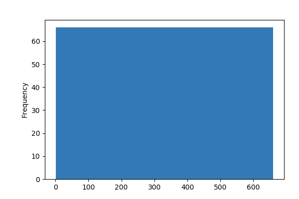

**Common Values**

| Value | Count | Frequency (%) |  |
| --- | --- | --- | --- |
| 660 | 1 | 0.2% |  |
| 226 | 1 | 0.2% |  |
| 224 | 1 | 0.2% |  |
| 223 | 1 | 0.2% |  |
| 222 | 1 | 0.2% |  |
| 221 | 1 | 0.2% |  |
| 220 | 1 | 0.2% |  |
| 219 | 1 | 0.2% |  |
| 218 | 1 | 0.2% |  |
| 217 | 1 | 0.2% |  |
| Other values (650) | 650 | 98.5% |  |

**Extreme Values**

Minimum 5 values

| Value | Count | Frequency (%) |  |
| --- | --- | --- | --- |
| 1 | 1 | 0.2% |  |
| 2 | 1 | 0.2% |  |
| 3 | 1 | 0.2% |  |
| 4 | 1 | 0.2% |  |
| 5 | 1 | 0.2% |  |

Maximum 5 values

| Value | Count | Frequency (%) |  |
| --- | --- | --- | --- |
| 656 | 1 | 0.2% |  |
| 657 | 1 | 0.2% |  |
| 658 | 1 | 0.2% |  |
| 659 | 1 | 0.2% |  |
| 660 | 1 | 0.2% |  |

Customer Key  
Numeric

| Distinct count | 655 |
| --- | --- |
| Unique (%) | 99.2% |
| Missing (%) | 0.0% |
| Missing (n) | 0 |
| Infinite (%) | 0.0% |
| Infinite (n) | 0 |

| Mean | 55141 |
| --- | --- |
| Minimum | 11265 |
| Maximum | 99843 |
| Zeros (%) | 0.0% |

Toggle details

**Statistics**

Quantile statistics

| Minimum | 11265 |
| --- | --- |
| 5-th percentile | 15318 |
| Q1 | 33825 |
| Median | 53874 |
| Q3 | 77202 |
| 95-th percentile | 96301 |
| Maximum | 99843 |
| Range | 88578 |
| Interquartile range | 43377 |

Descriptive statistics

| Standard deviation | 25628 |
| --- | --- |
| Coef of variation | 0.46476 |
| Kurtosis | -1.1476 |
| Mean | 55141 |
| MAD | 21959 |
| Skewness | 0.051462 |
| Sum | 36393353 |
| Variance | 656780000 |
| Memory size | 5.3 KiB |

**Histogram**

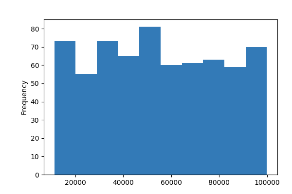

**Common Values**

| Value | Count | Frequency (%) |  |
| --- | --- | --- | --- |
| 47437 | 2 | 0.3% |  |
| 37252 | 2 | 0.3% |  |
| 97935 | 2 | 0.3% |  |
| 96929 | 2 | 0.3% |  |
| 50706 | 2 | 0.3% |  |
| 75775 | 1 | 0.2% |  |
| 43679 | 1 | 0.2% |  |
| 33295 | 1 | 0.2% |  |
| 67911 | 1 | 0.2% |  |
| 94529 | 1 | 0.2% |  |
| Other values (645) | 645 | 97.7% |  |

**Extreme Values**

Minimum 5 values

| Value | Count | Frequency (%) |  |
| --- | --- | --- | --- |
| 11265 | 1 | 0.2% |  |
| 11398 | 1 | 0.2% |  |
| 11412 | 1 | 0.2% |  |
| 11466 | 1 | 0.2% |  |
| 11562 | 1 | 0.2% |  |

Maximum 5 values

| Value | Count | Frequency (%) |  |
| --- | --- | --- | --- |
| 99437 | 1 | 0.2% |  |
| 99473 | 1 | 0.2% |  |
| 99589 | 1 | 0.2% |  |
| 99596 | 1 | 0.2% |  |
| 99843 | 1 | 0.2% |  |

Avg_Credit_Limit  
Numeric

| Distinct count | 110 |
| --- | --- |
| Unique (%) | 16.7% |
| Missing (%) | 0.0% |
| Missing (n) | 0 |
| Infinite (%) | 0.0% |
| Infinite (n) | 0 |

| Mean | 34574 |
| --- | --- |
| Minimum | 3000 |
| Maximum | 200000 |
| Zeros (%) | 0.0% |

Toggle details

**Statistics**

Quantile statistics

| Minimum | 3000 |
| --- | --- |
| 5-th percentile | 6000 |
| Q1 | 10000 |
| Median | 18000 |
| Q3 | 48000 |
| 95-th percentile | 121100 |
| Maximum | 200000 |
| Range | 197000 |
| Interquartile range | 38000 |

Descriptive statistics

| Standard deviation | 37625 |
| --- | --- |
| Coef of variation | 1.0883 |
| Kurtosis | 5.1338 |
| Mean | 34574 |
| MAD | 27071 |
| Skewness | 2.2024 |
| Sum | 22819000 |
| Variance | 1415700000 |
| Memory size | 5.3 KiB |

**Histogram**

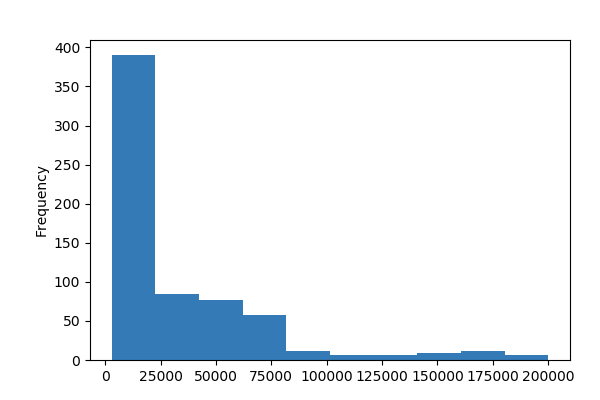

**Common Values**

| Value | Count | Frequency (%) |  |
| --- | --- | --- | --- |
| 8000 | 35 | 5.3% |  |
| 6000 | 31 | 4.7% |  |
| 9000 | 28 | 4.2% |  |
| 13000 | 28 | 4.2% |  |
| 10000 | 26 | 3.9% |  |
| 19000 | 26 | 3.9% |  |
| 7000 | 24 | 3.6% |  |
| 11000 | 24 | 3.6% |  |
| 18000 | 23 | 3.5% |  |
| 14000 | 23 | 3.5% |  |
| Other values (100) | 392 | 59.4% |  |

**Extreme Values**

Minimum 5 values

| Value | Count | Frequency (%) |  |
| --- | --- | --- | --- |
| 3000 | 1 | 0.2% |  |
| 5000 | 21 | 3.2% |  |
| 6000 | 31 | 4.7% |  |
| 7000 | 24 | 3.6% |  |
| 8000 | 35 | 5.3% |  |

Maximum 5 values

| Value | Count | Frequency (%) |  |
| --- | --- | --- | --- |
| 184000 | 1 | 0.2% |  |
| 186000 | 1 | 0.2% |  |
| 187000 | 1 | 0.2% |  |
| 195000 | 2 | 0.3% |  |
| 200000 | 1 | 0.2% |  |

Total_Credit_Cards  
Numeric

| Distinct count | 10 |
| --- | --- |
| Unique (%) | 1.5% |
| Missing (%) | 0.0% |
| Missing (n) | 0 |
| Infinite (%) | 0.0% |
| Infinite (n) | 0 |

| Mean | 4.7061 |
| --- | --- |
| Minimum | 1 |
| Maximum | 10 |
| Zeros (%) | 0.0% |

Toggle details

**Statistics**

Quantile statistics

| Minimum | 1 |
| --- | --- |
| 5-th percentile | 1 |
| Q1 | 3 |
| Median | 5 |
| Q3 | 6 |
| 95-th percentile | 8 |
| Maximum | 10 |
| Range | 9 |
| Interquartile range | 3 |

Descriptive statistics

| Standard deviation | 2.1678 |
| --- | --- |
| Coef of variation | 0.46065 |
| Kurtosis | -0.36977 |
| Mean | 4.7061 |
| MAD | 1.7845 |
| Skewness | 0.14488 |
| Sum | 3106 |
| Variance | 4.6995 |
| Memory size | 5.3 KiB |

**Histogram**

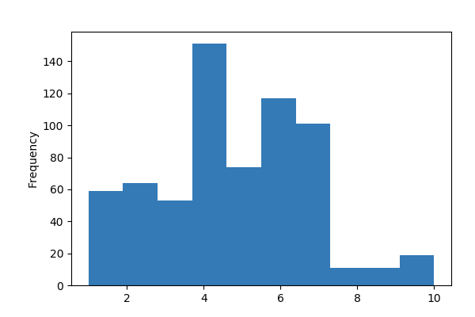

**Common Values**

| Value | Count | Frequency (%) |  |
| --- | --- | --- | --- |
| 4 | 151 | 22.9% |  |
| 6 | 117 | 17.7% |  |
| 7 | 101 | 15.3% |  |
| 5 | 74 | 11.2% |  |
| 2 | 64 | 9.7% |  |
| 1 | 59 | 8.9% |  |
| 3 | 53 | 8.0% |  |
| 10 | 19 | 2.9% |  |
| 9 | 11 | 1.7% |  |
| 8 | 11 | 1.7% |  |

**Extreme Values**

Minimum 5 values

| Value | Count | Frequency (%) |  |
| --- | --- | --- | --- |
| 1 | 59 | 8.9% |  |
| 2 | 64 | 9.7% |  |
| 3 | 53 | 8.0% |  |
| 4 | 151 | 22.9% |  |
| 5 | 74 | 11.2% |  |

Maximum 5 values

| Value | Count | Frequency (%) |  |
| --- | --- | --- | --- |
| 6 | 117 | 17.7% |  |
| 7 | 101 | 15.3% |  |
| 8 | 11 | 1.7% |  |
| 9 | 11 | 1.7% |  |
| 10 | 19 | 2.9% |  |

Total_visits_bank  
Numeric

| Distinct count | 6 |
| --- | --- |
| Unique (%) | 0.9% |
| Missing (%) | 0.0% |
| Missing (n) | 0 |
| Infinite (%) | 0.0% |
| Infinite (n) | 0 |

| Mean | 2.403 |
| --- | --- |
| Minimum | 0 |
| Maximum | 5 |
| Zeros (%) | 15.2% |

Toggle details

**Statistics**

Quantile statistics

| Minimum | 0 |
| --- | --- |
| 5-th percentile | 0 |
| Q1 | 1 |
| Median | 2 |
| Q3 | 4 |
| 95-th percentile | 5 |
| Maximum | 5 |
| Range | 5 |
| Interquartile range | 3 |

Descriptive statistics

| Standard deviation | 1.6318 |
| --- | --- |
| Coef of variation | 0.67906 |
| Kurtosis | -1.1043 |
| Mean | 2.403 |
| MAD | 1.3973 |
| Skewness | 0.1419 |
| Sum | 1586 |
| Variance | 2.6628 |
| Memory size | 5.3 KiB |

**Histogram**

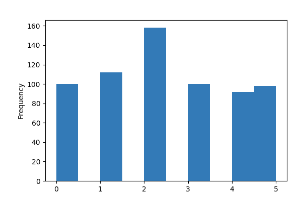

**Common Values**

| Value | Count | Frequency (%) |  |
| --- | --- | --- | --- |
| 2 | 158 | 23.9% |  |
| 1 | 112 | 17.0% |  |
| 3 | 100 | 15.2% |  |
| 0 | 100 | 15.2% |  |
| 5 | 98 | 14.8% |  |
| 4 | 92 | 13.9% |  |

**Extreme Values**

Minimum 5 values

| Value | Count | Frequency (%) |  |
| --- | --- | --- | --- |
| 0 | 100 | 15.2% |  |
| 1 | 112 | 17.0% |  |
| 2 | 158 | 23.9% |  |
| 3 | 100 | 15.2% |  |
| 4 | 92 | 13.9% |  |

Maximum 5 values

| Value | Count | Frequency (%) |  |
| --- | --- | --- | --- |
| 1 | 112 | 17.0% |  |
| 2 | 158 | 23.9% |  |
| 3 | 100 | 15.2% |  |
| 4 | 92 | 13.9% |  |
| 5 | 98 | 14.8% |  |

Total_visits_online  
Numeric

| Distinct count | 16 |
| --- | --- |
| Unique (%) | 2.4% |
| Missing (%) | 0.0% |
| Missing (n) | 0 |
| Infinite (%) | 0.0% |
| Infinite (n) | 0 |

| Mean | 2.6061 |
| --- | --- |
| Minimum | 0 |
| Maximum | 15 |
| Zeros (%) | 21.8% |

Toggle details

**Statistics**

Quantile statistics

| Minimum | 0 |
| --- | --- |
| 5-th percentile | 0 |
| Q1 | 1 |
| Median | 2 |
| Q3 | 4 |
| 95-th percentile | 9.05 |
| Maximum | 15 |
| Range | 15 |
| Interquartile range | 3 |

Descriptive statistics

| Standard deviation | 2.9357 |
| --- | --- |
| Coef of variation | 1.1265 |
| Kurtosis | 5.7396 |
| Mean | 2.6061 |
| MAD | 2.0148 |
| Skewness | 2.2256 |
| Sum | 1720 |
| Variance | 8.6185 |
| Memory size | 5.3 KiB |

**Histogram**

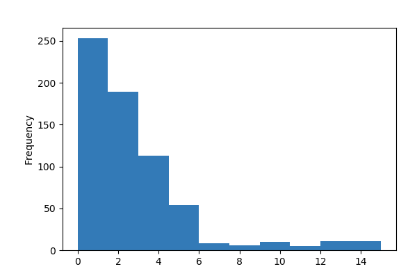

**Common Values**

| Value | Count | Frequency (%) |  |
| --- | --- | --- | --- |
| 2 | 189 | 28.6% |  |
| 0 | 144 | 21.8% |  |
| 1 | 109 | 16.5% |  |
| 4 | 69 | 10.5% |  |
| 5 | 54 | 8.2% |  |
| 3 | 44 | 6.7% |  |
| 15 | 10 | 1.5% |  |
| 7 | 7 | 1.1% |  |
| 12 | 6 | 0.9% |  |
| 10 | 6 | 0.9% |  |
| Other values (6) | 22 | 3.3% |  |

**Extreme Values**

Minimum 5 values

| Value | Count | Frequency (%) |  |
| --- | --- | --- | --- |
| 0 | 144 | 21.8% |  |
| 1 | 109 | 16.5% |  |
| 2 | 189 | 28.6% |  |
| 3 | 44 | 6.7% |  |
| 4 | 69 | 10.5% |  |

Maximum 5 values

| Value | Count | Frequency (%) |  |
| --- | --- | --- | --- |
| 11 | 5 | 0.8% |  |
| 12 | 6 | 0.9% |  |
| 13 | 5 | 0.8% |  |
| 14 | 1 | 0.2% |  |
| 15 | 10 | 1.5% |  |

Total_calls_made  
Numeric

| Distinct count | 11 |
| --- | --- |
| Unique (%) | 1.7% |
| Missing (%) | 0.0% |
| Missing (n) | 0 |
| Infinite (%) | 0.0% |
| Infinite (n) | 0 |

| Mean | 3.5833 |
| --- | --- |
| Minimum | 0 |
| Maximum | 10 |
| Zeros (%) | 14.7% |

Toggle details

**Statistics**

Quantile statistics

| Minimum | 0 |
| --- | --- |
| 5-th percentile | 0 |
| Q1 | 1 |
| Median | 3 |
| Q3 | 5 |
| 95-th percentile | 9 |
| Maximum | 10 |
| Range | 10 |
| Interquartile range | 4 |

Descriptive statistics

| Standard deviation | 2.8653 |
| --- | --- |
| Coef of variation | 0.79962 |
| Kurtosis | -0.51826 |
| Mean | 3.5833 |
| MAD | 2.3412 |
| Skewness | 0.65891 |
| Sum | 2365 |
| Variance | 8.21 |
| Memory size | 5.3 KiB |

**Histogram**

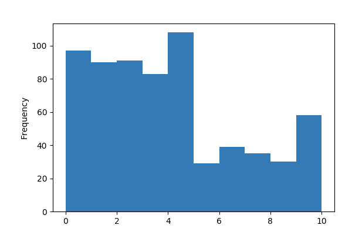

**Common Values**

| Value | Count | Frequency (%) |  |
| --- | --- | --- | --- |
| 4 | 108 | 16.4% |  |
| 0 | 97 | 14.7% |  |
| 2 | 91 | 13.8% |  |
| 1 | 90 | 13.6% |  |
| 3 | 83 | 12.6% |  |
| 6 | 39 | 5.9% |  |
| 7 | 35 | 5.3% |  |
| 9 | 32 | 4.8% |  |
| 8 | 30 | 4.5% |  |
| 5 | 29 | 4.4% |  |

**Extreme Values**

Minimum 5 values

| Value | Count | Frequency (%) |  |
| --- | --- | --- | --- |
| 0 | 97 | 14.7% |  |
| 1 | 90 | 13.6% |  |
| 2 | 91 | 13.8% |  |
| 3 | 83 | 12.6% |  |
| 4 | 108 | 16.4% |  |

Maximum 5 values

| Value | Count | Frequency (%) |  |
| --- | --- | --- | --- |
| 6 | 39 | 5.9% |  |
| 7 | 35 | 5.3% |  |
| 8 | 30 | 4.5% |  |
| 9 | 32 | 4.8% |  |
| 10 | 26 | 3.9% |  |

Correlations

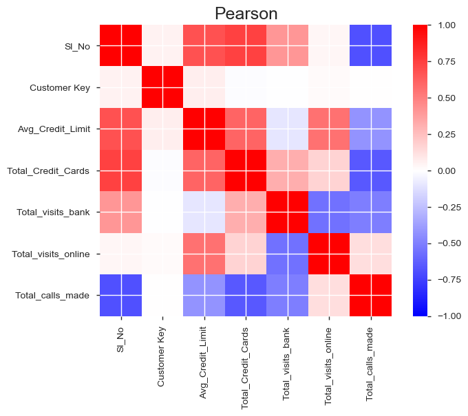

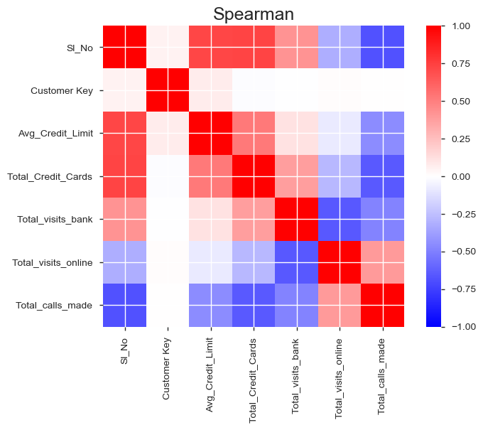

Sample

| Sl_No | Customer Key | Avg_Credit_Limit | Total_Credit_Cards | Total_visits_bank | Total_visits_online | Total_calls_made |
| --- | --- | --- | --- | --- | --- | --- |
| 1 | 87073 | 100000 | 2 | 1 | 1 | 0 |
| 2 | 38414 | 50000 | 3 | 0 | 10 | 9 |
| 3 | 17341 | 50000 | 7 | 1 | 3 | 4 |
| 4 | 40496 | 30000 | 5 | 1 | 1 | 4 |
| 5 | 47437 | 100000 | 6 | 0 | 12 | 3 |

```python
from pandas_profiling import ProfileReport
ProfileReport(df)
```

```python
df['Total_Credit_Cards'].value_counts()
```

```
4     151
6     117
7     101
5      74
2      64
1      59
3      53
10     19
9      11
8      11
Name: Total_Credit_Cards, dtype: int64
```

```python
moreCards = df[df['Total_Credit_Cards'] > 3].count()
moreCards
```

```
Customer Key           484
Avg_Credit_Limit       484
Total_Credit_Cards     484
Total_visits_bank      484
Total_visits_online    484
Total_calls_made       484
dtype: int64
```

```python
df[(df['Total_visits_bank'] == 0) & (df['Total_visits_online'] == 0)].count()
```

```
Customer Key           0
Avg_Credit_Limit       0
Total_Credit_Cards     0
Total_visits_bank      0
Total_visits_online    0
Total_calls_made       0
dtype: int64
```

# Comment

A customer has atleast visited bank personally or online.

```python
df[df['Total_visits_bank'] == 0].count()
```

```
Customer Key           100
Avg_Credit_Limit       100
Total_Credit_Cards     100
Total_visits_bank      100
Total_visits_online    100
Total_calls_made       100
dtype: int64
```

```python
df[df['Total_visits_online'] == 0].count()
```

```
Customer Key           144
Avg_Credit_Limit       144
Total_Credit_Cards     144
Total_visits_bank      144
Total_visits_online    144
Total_calls_made       144
dtype: int64
```

```python
df[df['Total_calls_made'] == 0].count()
```

```
Customer Key           97
Avg_Credit_Limit       97
Total_Credit_Cards     97
Total_visits_bank      97
Total_visits_online    97
Total_calls_made       97
dtype: int64
```

```python
df[(df['Total_visits_bank'] == 0) & (df['Total_Credit_Cards'] <= 3)].count()
```

```
Customer Key           67
Avg_Credit_Limit       67
Total_Credit_Cards     67
Total_visits_bank      67
Total_visits_online    67
Total_calls_made       67
dtype: int64
```

```python
df[(df['Total_visits_online'] == 0) & (df['Total_Credit_Cards'] <= 3)].count()
```

```
Customer Key           0
Avg_Credit_Limit       0
Total_Credit_Cards     0
Total_visits_bank      0
Total_visits_online    0
Total_calls_made       0
dtype: int64
```

```python
df[(df['Total_calls_made'] == 0) & (df['Total_Credit_Cards'] <= 3)].count()
```

```
Customer Key           1
Avg_Credit_Limit       1
Total_Credit_Cards     1
Total_visits_bank      1
Total_visits_online    1
Total_calls_made       1
dtype: int64
```

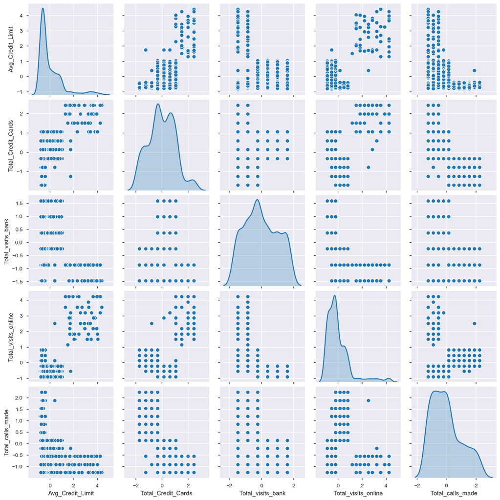

```python
#Bivariate

creditAttr=df.iloc[:,1:]
creditAttrScaled=creditAttr.apply(zscore)
sns.pairplot(creditAttrScaled,diag_kind='kde')
```

# Comment

From above pairplot, we can see that 'Avg_Credit_Limit' has direct relation to 'Total_Credit_Cards' (this is obvious) and 'Total_visits_online'. At the same time, it has inverse relation to 'Total_visits_bank' and 'Total_calls_made'

```python
corr = creditAttr.corr()
```

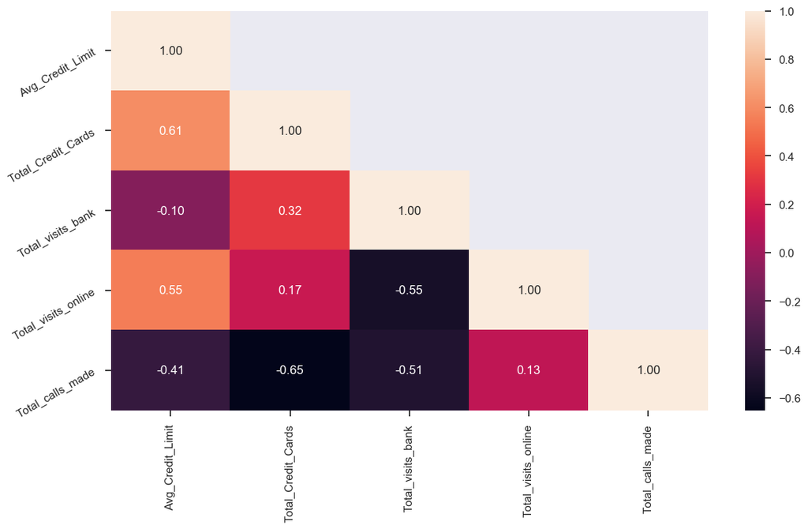

```python
sns.set_context("notebook", font_scale=1.0, rc={"lines.linewidth": 2.5})
plt.figure(figsize=(13,7))
# create a mask so we only see the correlation values once
mask = np.zeros_like(corr)
mask[np.triu_indices_from(mask, 1)] = True
a = sns.heatmap(corr,mask=mask, annot=True, fmt='.2f')
rotx = a.set_xticklabels(a.get_xticklabels(), rotation=90)
roty = a.set_yticklabels(a.get_yticklabels(), rotation=30)
```

# Comment

1. Heatmap confirms pairplot analysis. The column 'Avg_Credit_Limit' is highly correlated with 'Total_visits_online' and is inversely correlated with 'Total_calls_made'.
2. The customers who visit online or even make calls seems to visit bank less. This will be useful for improving customer care.
3. The 'Total_calls_made' is highly inversely related to 'Total_Credit_Cards'. The customers who make calls have less credit cards.

# 2. Properly comment on the codes, provide explanations of the steps taken in the notebook and conclude your insights from the graphs. (5 marks)

From above, there are naturally two groups present. First group who likes to visit bank often and like to resolve business in person. Other group prefers to do transactions or resolve queries remotely. This segmentation is using customer's past interaction pattern with the bank.

Other group could be customers having more credit limit and more credit cards.

# Scaling

```python
df.drop(columns = {'Customer Key'}, inplace=True)
```

```python
df.shape
```

```
(660, 5)
```

```python
##Scale the data
from scipy.stats import zscore

df_z = df.apply(zscore)
```

# 3. Execute K-means clustering use elbow plot and analyse clusters using boxplot (10 marks)

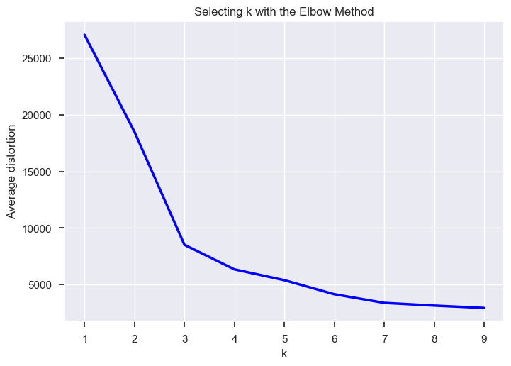

```python
from scipy.spatial.distance import cdist
from sklearn.cluster import KMeans

clusters=range(1,10)
meanDistortions=[]

for k in clusters:
    model=KMeans(n_clusters=k)
    model.fit(df)
    prediction=model.predict(df)
    meanDistortions.append(sum(np.min(cdist(df, model.cluster_centers_, 'euclidean'), axis=1)) / df
                           .shape[0])


plt.plot(clusters, meanDistortions, 'bx-')
plt.xlabel('k')
plt.ylabel('Average distortion')
plt.title('Selecting k with the Elbow Method')
```

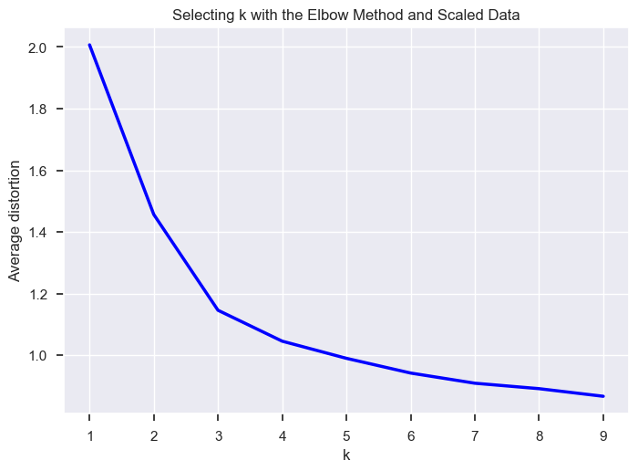

```python
# Apply on scaled data

clusters=range(1,10)
meanDistortions=[]

for k in clusters:
    model=KMeans(n_clusters=k)
    model.fit(df_z)
    prediction=model.predict(df_z)
    meanDistortions.append(sum(np.min(cdist(df_z, model.cluster_centers_, 'euclidean'), axis=1)) / df_z
                           .shape[0])


plt.plot(clusters, meanDistortions, 'bx-')
plt.xlabel('k')
plt.ylabel('Average distortion')
plt.title('Selecting k with the Elbow Method and Scaled Data')
```

# Comment

We are going to use scaled data Elbow method.

We can use K= 2, K = 3 or K = 4

```python
# Let us first start with K = 2
kmeans2model=KMeans(2)
kmeans2model.fit(df_z)
```

```
KMeans(algorithm='auto', copy_x=True, init='k-means++', max_iter=300,
       n_clusters=2, n_init=10, n_jobs=None, precompute_distances='auto',
       random_state=None, tol=0.0001, verbose=0)
```

```python
centroids = kmeans2model.cluster_centers_
centroids
```

```
array([[-0.59579625, -1.05962278, -0.9015185 ,  0.32299678,  1.14810882],
       [ 0.30609715,  0.54439335,  0.46316547, -0.1659433 , -0.58985407]])
```

```python
#Calculate the centroids for the columns to profile
centroid_df = pd.DataFrame(centroids, columns = list(df_z) )
print(centroid_df)
```

```
   Avg_Credit_Limit  Total_Credit_Cards  Total_visits_bank  \
0         -0.595796           -1.059623          -0.901518
1          0.306097            0.544393           0.463165

   Total_visits_online  Total_calls_made
0             0.322997          1.148109
1            -0.165943         -0.589854
```

```python
prediction2=kmeans2model.predict(df_z)
```

```python
#Append the prediction
df["GROUP"] = prediction2
df_z["GROUP"] = prediction2
print("Groups Assigned : \n")
df.head()
```

```
Groups Assigned :
```

| Sl_No | Avg_Credit_Limit | Total_Credit_Cards | Total_visits_bank | Total_visits_online | Total_calls_made | GROUP |
| --- | --- | --- | --- | --- | --- | --- |
| 1 | 100000 | 2 | 1 | 1 | 0 | 1 |
| 2 | 50000 | 3 | 0 | 10 | 9 | 0 |
| 3 | 50000 | 7 | 1 | 3 | 4 | 1 |
| 4 | 30000 | 5 | 1 | 1 | 4 | 1 |
| 5 | 100000 | 6 | 0 | 12 | 3 | 1 |

```python
df2Clust = df.groupby(['GROUP'])
df2Clust.mean()
```

| GROUP | Avg_Credit_Limit | Total_Credit_Cards | Total_visits_bank | Total_visits_online | Total_calls_made |
| --- | --- | --- | --- | --- | --- |
| 0 | 12174.107143 | 2.410714 | 0.933036 | 3.553571 | 6.870536 |
| 1 | 46082.568807 | 5.885321 | 3.158257 | 2.119266 | 1.894495 |

```
array([[<matplotlib.axes._subplots.AxesSubplot object at 0x000001C103EBE208>,
      dtype=object)
```

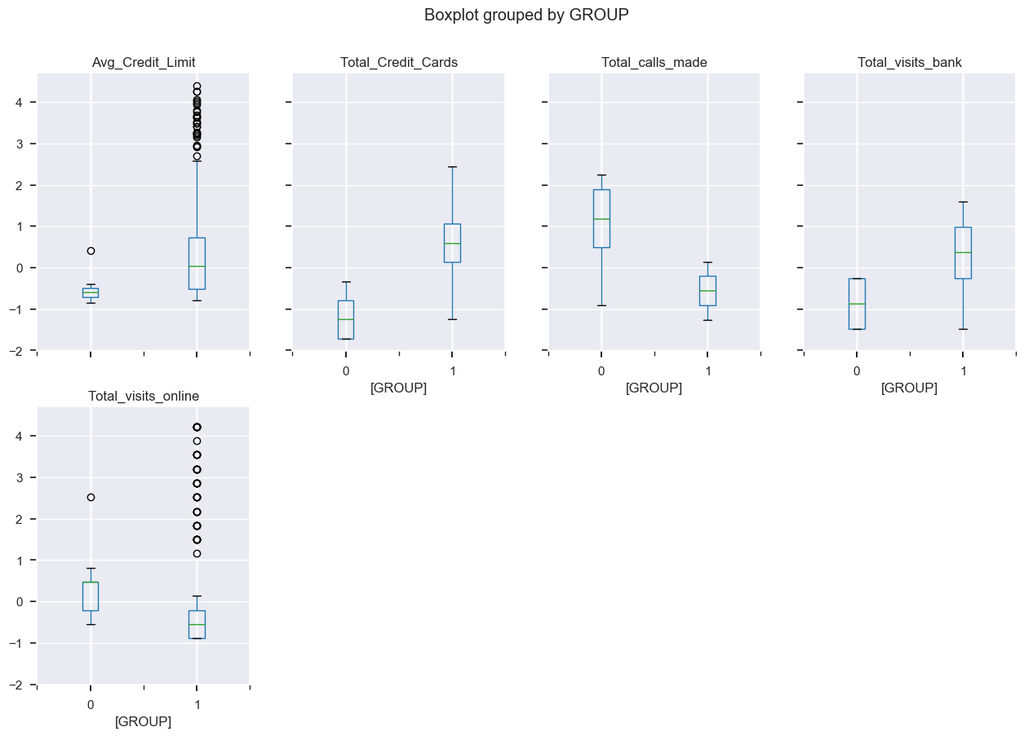

```python
df_z.boxplot(by='GROUP', layout = (2,4),figsize=(15,10))
```

```python
# Now K = 3
kmeans3model=KMeans(3)
kmeans3model.fit(df_z)
```

```
KMeans(algorithm='auto', copy_x=True, init='k-means++', max_iter=300,
       n_clusters=3, n_init=10, n_jobs=None, precompute_distances='auto',
       random_state=None, tol=0.0001, verbose=0)
```

```python
kmeans3centroids = kmeans3model.cluster_centers_
kmeans3centroids
```

```
array([[-2.10617756e-02,  3.73689617e-01,  6.66394501e-01,
        -5.53671634e-01, -5.53004884e-01,  1.00000000e+00],
       [-5.95796246e-01, -1.05962278e+00, -9.01518495e-01,
         3.22996784e-01,  1.14810882e+00,  1.66533454e-15],
       [ 2.83176409e+00,  1.86222621e+00, -1.10576269e+00,
         2.82731942e+00, -8.74329826e-01,  1.00000000e+00]])
```

```python
#Calculate the centroids for the columns to profile
centroid_df = pd.DataFrame(kmeans3centroids, columns = list(df_z) )
print(centroid_df)
```

```
   Avg_Credit_Limit  Total_Credit_Cards  Total_visits_bank  \
0         -0.021062            0.373690           0.666395
1         -0.595796           -1.059623          -0.901518
2          2.831764            1.862226          -1.105763

   Total_visits_online  Total_calls_made         GROUP
0            -0.553672         -0.553005  1.000000e+00
1             0.322997          1.148109  1.665335e-15
2             2.827319         -0.874330  1.000000e+00
```

```python
prediction3=kmeans3model.predict(df_z)
prediction3
```

```
array([0, 1, 0, 0, 2, 1, 2, 1, 1, 1, 1, 1, 1, 1, 1, 1, 1, 1, 1, 1, 1, 1,
       1, 1, 1, 1, 1, 1, 1, 1, 1, 1, 1, 1, 1, 1, 1, 1, 1, 1, 1, 1, 1, 1,
       1, 1, 1, 1, 1, 1, 1, 1, 1, 1, 1, 1, 1, 1, 1, 1, 1, 1, 1, 1, 1, 1,
       1, 1, 1, 1, 1, 1, 1, 1, 1, 1, 1, 1, 1, 1, 1, 1, 1, 1, 1, 1, 1, 1,
       1, 1, 1, 1, 1, 1, 1, 1, 1, 1, 1, 1, 1, 1, 1, 1, 1, 1, 1, 1, 1, 1,
       1, 1, 1, 1, 1, 1, 1, 1, 1, 1, 1, 1, 1, 1, 1, 1, 1, 1, 1, 1, 1, 1,
       1, 1, 1, 1, 1, 1, 1, 1, 1, 1, 1, 1, 1, 1, 1, 1, 1, 1, 1, 1, 1, 1,
       1, 1, 1, 1, 1, 1, 1, 1, 1, 1, 1, 1, 1, 1, 1, 1, 1, 1, 1, 1, 1, 1,
       1, 1, 1, 1, 1, 1, 1, 1, 1, 1, 1, 1, 1, 1, 1, 1, 1, 1, 1, 1, 1, 1,
       1, 1, 1, 1, 1, 1, 1, 1, 1, 1, 1, 1, 1, 1, 1, 1, 1, 1, 1, 1, 1, 1,
       1, 1, 1, 1, 1, 1, 1, 1, 0, 0, 0, 0, 0, 0, 0, 0, 0, 0, 0, 0, 0, 0,
       0, 0, 0, 0, 0, 0, 0, 0, 0, 0, 0, 0, 0, 0, 0, 0, 0, 0, 0, 0, 0, 0,
       0, 0, 0, 0, 0, 0, 0, 0, 0, 0, 0, 0, 0, 0, 0, 0, 0, 0, 0, 0, 0, 0,
       0, 0, 0, 0, 0, 0, 0, 0, 0, 0, 0, 0, 0, 0, 0, 0, 0, 0, 0, 0, 0, 0,
       0, 0, 0, 0, 0, 1, 0, 0, 0, 0, 0, 0, 0, 0, 0, 0, 0, 0, 0, 0, 0, 0,
       0, 0, 0, 0, 0, 0, 0, 0, 0, 0, 0, 0, 0, 0, 0, 0, 0, 0, 0, 0, 0, 0,
       0, 0, 0, 0, 0, 0, 0, 0, 0, 0, 0, 0, 0, 0, 0, 0, 0, 0, 0, 0, 0, 0,
       0, 0, 0, 0, 0, 0, 0, 0, 0, 0, 0, 0, 0, 0, 0, 0, 0, 0, 0, 0, 0, 0,
       0, 0, 0, 0, 0, 0, 0, 0, 0, 0, 0, 0, 0, 0, 0, 0, 0, 0, 0, 0, 0, 0,
       0, 0, 0, 0, 0, 0, 0, 0, 0, 0, 0, 0, 0, 0, 0, 0, 0, 0, 0, 0, 0, 0,
       0, 0, 0, 0, 0, 0, 0, 0, 0, 0, 0, 0, 0, 0, 0, 0, 0, 0, 0, 0, 0, 0,
       0, 0, 0, 0, 0, 0, 0, 0, 0, 0, 0, 0, 0, 0, 0, 0, 0, 0, 0, 0, 0, 0,
       0, 0, 0, 0, 0, 0, 0, 0, 0, 0, 0, 0, 0, 0, 0, 0, 0, 0, 0, 0, 0, 0,
       0, 0, 0, 0, 0, 0, 0, 0, 0, 0, 0, 0, 0, 0, 0, 0, 0, 0, 0, 0, 0, 0,
       0, 0, 0, 0, 0, 0, 0, 0, 0, 0, 0, 0, 0, 0, 0, 0, 0, 0, 0, 0, 0, 0,
       0, 0, 0, 0, 0, 0, 0, 0, 0, 0, 0, 0, 0, 0, 0, 0, 0, 0, 0, 0, 0, 0,
       0, 0, 0, 0, 0, 0, 0, 0, 0, 0, 0, 0, 0, 0, 0, 0, 0, 0, 0, 0, 0, 0,
       0, 0, 0, 0, 0, 0, 0, 0, 0, 0, 0, 0, 0, 0, 0, 0, 0, 0, 2, 2, 2, 2,
       2, 2, 2, 2, 2, 2, 2, 2, 2, 2, 2, 2, 2, 2, 2, 2, 2, 2, 2, 2, 2, 2,
       2, 2, 2, 2, 2, 2, 2, 2, 2, 2, 2, 2, 2, 2, 2, 2, 2, 2, 2, 2, 2, 2])
```

```python
df["GROUP"] = prediction3
df_z["GROUP"] = prediction3
print("Groups Assigned : \n")
df.head()
```

```
Groups Assigned :
```

| Sl_No | Avg_Credit_Limit | Total_Credit_Cards | Total_visits_bank | Total_visits_online | Total_calls_made | GROUP |
| --- | --- | --- | --- | --- | --- | --- |
| 1 | 100000 | 2 | 1 | 1 | 0 | 0 |
| 2 | 50000 | 3 | 0 | 10 | 9 | 1 |
| 3 | 50000 | 7 | 1 | 3 | 4 | 0 |
| 4 | 30000 | 5 | 1 | 1 | 4 | 0 |
| 5 | 100000 | 6 | 0 | 12 | 3 | 2 |

```python
df3Clust = df.groupby(['GROUP'])

df3Clust.mean()
```

| GROUP | Avg_Credit_Limit | Total_Credit_Cards | Total_visits_bank | Total_visits_online | Total_calls_made |
| --- | --- | --- | --- | --- | --- |
| 0 | 33782.383420 | 5.515544 | 3.489637 | 0.981865 | 2.000000 |
| 1 | 12174.107143 | 2.410714 | 0.933036 | 3.553571 | 6.870536 |
| 2 | 141040.000000 | 8.740000 | 0.600000 | 10.900000 | 1.080000 |

```
array([[<matplotlib.axes._subplots.AxesSubplot object at 0x000001C1029550C8>,
      dtype=object)
```

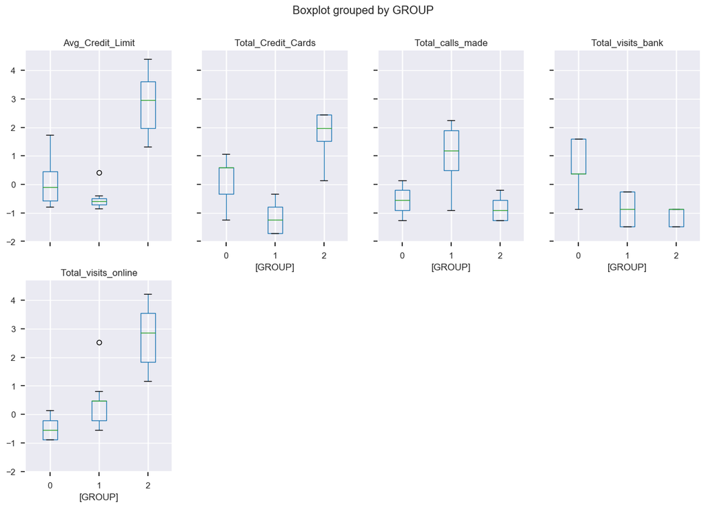

```python
df_z.boxplot(by='GROUP', layout = (2,4),figsize=(15,10))
```

```python
# Let us try with K = 3 (to demonstrate the 3d plot using mplot3d)
from mpl_toolkits.mplot3d import Axes3D
```

[figure not shown]

```python
fig = plt.figure(figsize=(8, 6))
ax = Axes3D(fig, rect=[0, 0, .95, 1], elev=20, azim=60)
labels = kmeans3model.labels_
ax.scatter(df_z.iloc[:, 0], df_z.iloc[:, 1], df_z.iloc[:, 2],c=labels.astype(np.float), edgecolor='k')
ax.w_xaxis.set_ticklabels([])
ax.w_yaxis.set_ticklabels([])
ax.w_zaxis.set_ticklabels([])
ax.set_xlabel('Length')
ax.set_ylabel('Height')
ax.set_zlabel('Weight')
ax.set_title('3D plot of KMeans Clustering')
```

```python
# Now K = 4
kmeans4model=KMeans(4)
kmeans4model.fit(df_z)
```

```
KMeans(algorithm='auto', copy_x=True, init='k-means++', max_iter=300,
       n_clusters=4, n_init=10, n_jobs=None, precompute_distances='auto',
       random_state=None, tol=0.0001, verbose=0)
```

```python
centroids = kmeans4model.cluster_centers_
centroids
```

```
array([[ 4.19725771e-02,  3.84088984e-01,  4.85737497e-02,
        -5.63063341e-01, -5.33502708e-01,  5.07614213e-03],
       [-5.96133299e-01, -1.06084268e+00, -8.98952521e-01,
         3.26900311e-01,  1.15730335e+00,  1.00000000e+00],
       [ 2.83176409e+00,  1.86222621e+00, -1.10576269e+00,
         2.82731942e+00, -8.74329826e-01,  2.00000000e+00],
       [-8.90477712e-02,  3.56795143e-01,  1.29571325e+00,
        -5.43901381e-01, -5.75063804e-01,  1.27675648e-15]])
```

```python
#Calculate the centroids for the columns to profile
centroid_df = pd.DataFrame(centroids, columns = list(df_z) )
print(centroid_df)
```

```
   Avg_Credit_Limit  Total_Credit_Cards  Total_visits_bank  \
0          0.041973            0.384089           0.048574
1         -0.596133           -1.060843          -0.898953
2          2.831764            1.862226          -1.105763
3         -0.089048            0.356795           1.295713

   Total_visits_online  Total_calls_made         GROUP
0            -0.563063         -0.533503  5.076142e-03
1             0.326900          1.157303  1.000000e+00
2             2.827319         -0.874330  2.000000e+00
3            -0.543901         -0.575064  1.276756e-15
```

```python
prediction4=kmeans4model.predict(df_z)
prediction4
```

```
array([0, 1, 0, 0, 2, 1, 2, 0, 1, 1, 1, 1, 1, 1, 1, 1, 1, 1, 1, 1, 1, 1,
       1, 1, 1, 1, 1, 1, 1, 1, 1, 1, 1, 1, 1, 1, 1, 1, 1, 1, 1, 1, 1, 1,
       1, 1, 1, 1, 1, 1, 1, 1, 1, 1, 1, 1, 1, 1, 1, 1, 1, 1, 1, 1, 1, 1,
       1, 1, 1, 1, 1, 1, 1, 1, 1, 1, 1, 1, 1, 1, 1, 1, 1, 1, 1, 1, 1, 1,
       1, 1, 1, 1, 1, 1, 1, 1, 1, 1, 1, 1, 1, 1, 1, 1, 1, 1, 1, 1, 1, 1,
       1, 1, 1, 1, 1, 1, 1, 1, 1, 1, 1, 1, 1, 1, 1, 1, 1, 1, 1, 1, 1, 1,
       1, 1, 1, 1, 1, 1, 1, 1, 1, 1, 1, 1, 1, 1, 1, 1, 1, 1, 1, 1, 1, 1,
       1, 1, 1, 1, 1, 1, 1, 1, 1, 1, 1, 1, 1, 1, 1, 1, 1, 1, 1, 1, 1, 1,
       1, 1, 1, 1, 1, 1, 1, 1, 1, 1, 1, 1, 1, 1, 1, 1, 1, 1, 1, 1, 1, 1,
       1, 1, 1, 1, 1, 1, 1, 1, 1, 1, 1, 1, 1, 1, 1, 1, 1, 1, 1, 1, 1, 1,
       1, 1, 1, 1, 1, 1, 1, 1, 0, 0, 3, 0, 3, 0, 3, 3, 3, 3, 0, 0, 0, 3,
       0, 3, 0, 0, 3, 0, 3, 3, 0, 0, 3, 0, 0, 3, 0, 3, 0, 3, 3, 0, 3, 0,
       3, 3, 3, 3, 3, 3, 3, 0, 0, 3, 3, 0, 3, 3, 3, 3, 3, 0, 0, 0, 0, 3,
       3, 0, 0, 3, 0, 0, 0, 0, 3, 3, 3, 3, 3, 3, 3, 3, 0, 3, 3, 3, 0, 0,
       3, 3, 3, 0, 0, 1, 0, 0, 3, 3, 3, 0, 3, 3, 0, 0, 3, 3, 3, 3, 3, 3,
       0, 3, 0, 3, 3, 3, 3, 0, 0, 0, 0, 0, 3, 0, 0, 3, 0, 0, 3, 0, 0, 0,
       0, 3, 3, 3, 3, 3, 0, 0, 0, 0, 3, 0, 3, 3, 3, 0, 0, 3, 0, 0, 3, 3,
       3, 0, 3, 0, 3, 0, 0, 0, 0, 0, 3, 3, 0, 0, 3, 3, 0, 3, 3, 0, 3, 3,
       3, 0, 0, 0, 0, 3, 0, 0, 0, 0, 0, 3, 0, 0, 0, 3, 3, 3, 0, 0, 0, 3,
       0, 3, 0, 3, 0, 0, 3, 0, 0, 3, 3, 3, 3, 3, 0, 0, 0, 3, 0, 0, 0, 3,
       0, 0, 0, 3, 3, 3, 3, 0, 3, 0, 0, 3, 3, 3, 0, 0, 3, 0, 0, 3, 3, 3,
       3, 3, 0, 3, 0, 3, 3, 0, 3, 0, 0, 0, 0, 3, 3, 3, 0, 0, 0, 0, 0, 3,
       3, 0, 0, 3, 3, 3, 0, 3, 3, 0, 0, 0, 0, 0, 3, 3, 3, 0, 0, 0, 3, 0,
       3, 0, 0, 3, 0, 0, 0, 0, 0, 3, 3, 0, 3, 0, 3, 0, 3, 0, 0, 3, 0, 0,
       0, 0, 0, 0, 0, 0, 3, 3, 3, 0, 3, 3, 0, 3, 3, 0, 0, 3, 0, 3, 0, 3,
       3, 0, 0, 3, 0, 3, 3, 3, 3, 3, 0, 3, 0, 3, 3, 3, 3, 0, 3, 3, 0, 0,
       3, 0, 0, 0, 0, 0, 3, 0, 3, 3, 3, 0, 3, 3, 0, 0, 0, 3, 0, 0, 3, 3,
       0, 3, 3, 3, 3, 0, 3, 3, 3, 0, 0, 0, 0, 0, 3, 0, 0, 3, 2, 2, 2, 2,
       2, 2, 2, 2, 2, 2, 2, 2, 2, 2, 2, 2, 2, 2, 2, 2, 2, 2, 2, 2, 2, 2,
       2, 2, 2, 2, 2, 2, 2, 2, 2, 2, 2, 2, 2, 2, 2, 2, 2, 2, 2, 2, 2, 2])
```

```python
df["GROUP"] = prediction4
df_z["GROUP"] = prediction4
print("Groups Assigned : \n")
df.head()
```

```
Groups Assigned :
```

| Sl_No | Avg_Credit_Limit | Total_Credit_Cards | Total_visits_bank | Total_visits_online | Total_calls_made | GROUP |
| --- | --- | --- | --- | --- | --- | --- |
| 1 | 100000 | 2 | 1 | 1 | 0 | 0 |
| 2 | 50000 | 3 | 0 | 10 | 9 | 1 |
| 3 | 50000 | 7 | 1 | 3 | 4 | 0 |
| 4 | 30000 | 5 | 1 | 1 | 4 | 0 |
| 5 | 100000 | 6 | 0 | 12 | 3 | 2 |

```python
df4Clust = df.groupby(['GROUP'])
df4Clust.mean()
```

| GROUP | Avg_Credit_Limit | Total_Credit_Cards | Total_visits_bank | Total_visits_online | Total_calls_made |
| --- | --- | --- | --- | --- | --- |
| 0 | 36152.284264 | 5.538071 | 2.482234 | 0.954315 | 2.055838 |
| 1 | 12161.434978 | 2.408072 | 0.937220 | 3.565022 | 6.896861 |
| 2 | 141040.000000 | 8.740000 | 0.600000 | 10.900000 | 1.080000 |
| 3 | 31226.315789 | 5.478947 | 4.515789 | 1.010526 | 1.936842 |

```
array([[<matplotlib.axes._subplots.AxesSubplot object at 0x000001C1002FA848>,
      dtype=object)
```

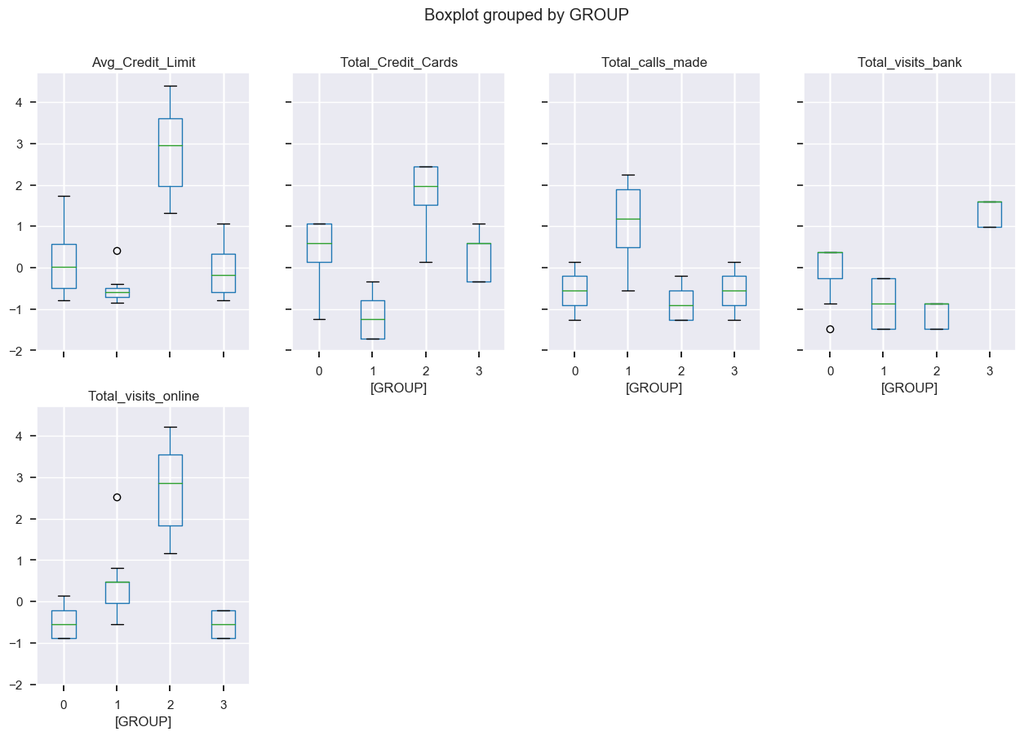

```python
df_z.boxplot(by='GROUP', layout = (2,4),figsize=(15,10))
```

# 4. Execute hierarchical clustering (with different linkages) with the help of dendrogram and cophenetic coeff. Analyse clusters formed using boxplot (15 marks)

```python
df_z.shape
```

```
(660, 6)
```

```python
df_z.drop(columns = {'GROUP'}, inplace=True)
```

```python
df_z.columns
```

```
Index(['Avg_Credit_Limit', 'Total_Credit_Cards', 'Total_visits_bank',
       'Total_visits_online', 'Total_calls_made'],
      dtype='object')
```

```python
from scipy.cluster.hierarchy import cophenet, dendrogram, linkage
```

```python
from scipy.spatial.distance import pdist  #Pairwise distribution between data points
```

# Average linkage

```python
# cophenet index is a measure of the correlation between the distance of points in feature space and distance on dendrogram
# closer it is to 1, the better is the clustering

Z_Avg = linkage(df_z, metric='euclidean', method='average')
c, coph_dists = cophenet(Z_Avg , pdist(df_z))

c
```

```
0.8977080867389372
```

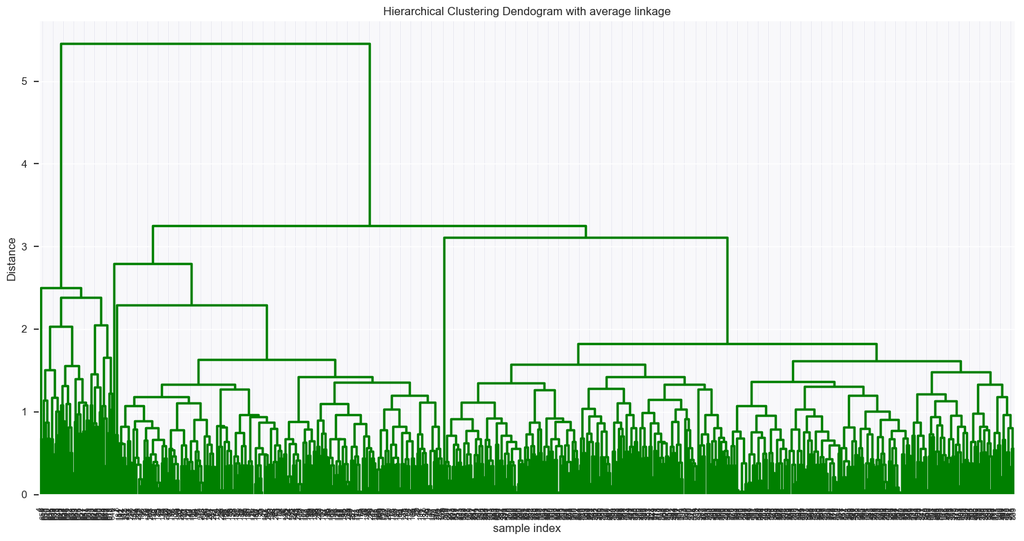

```python
plt.figure(figsize=(15, 8))
plt.title('Hierarchical Clustering Dendogram with average linkage')
plt.xlabel('sample index')
plt.ylabel('Distance')
dendrogram(Z_Avg, leaf_rotation=90.,color_threshold = 40, leaf_font_size=8. )
plt.tight_layout()
```

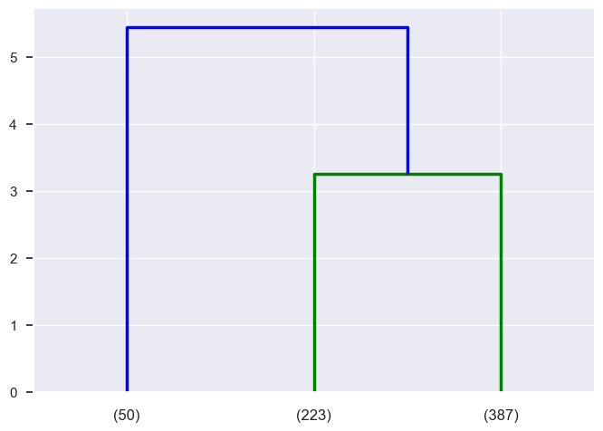

```python
# Hint: Use truncate_mode='lastp' attribute in dendrogram function to arrive at dendrogram
dendrogram(
    Z_Avg,
    truncate_mode='lastp',  # show only the last p merged clusters
    p=3,  # show only the last p merged clusters
)
plt.show()
```

```python
max_d = 52
```

```python
#from scipy.cluster.hierarchy import cut_tree
#cluster_labels = cut_tree(Z_Avg, n_clusters=3).reshape(-1, )

from scipy.cluster.hierarchy import fcluster
clusters = fcluster(Z_Avg, t= 5, criterion='distance')
```

```python
clusters
```

```
array([2, 2, 2, 2, 1, 2, 1, 2, 2, 2, 2, 2, 2, 2, 2, 2, 2, 2, 2, 2, 2, 2,
       2, 2, 2, 2, 2, 2, 2, 2, 2, 2, 2, 2, 2, 2, 2, 2, 2, 2, 2, 2, 2, 2,
       2, 2, 2, 2, 2, 2, 2, 2, 2, 2, 2, 2, 2, 2, 2, 2, 2, 2, 2, 2, 2, 2,
       2, 2, 2, 2, 2, 2, 2, 2, 2, 2, 2, 2, 2, 2, 2, 2, 2, 2, 2, 2, 2, 2,
       2, 2, 2, 2, 2, 2, 2, 2, 2, 2, 2, 2, 2, 2, 2, 2, 2, 2, 2, 2, 2, 2,
       2, 2, 2, 2, 2, 2, 2, 2, 2, 2, 2, 2, 2, 2, 2, 2, 2, 2, 2, 2, 2, 2,
       2, 2, 2, 2, 2, 2, 2, 2, 2, 2, 2, 2, 2, 2, 2, 2, 2, 2, 2, 2, 2, 2,
       2, 2, 2, 2, 2, 2, 2, 2, 2, 2, 2, 2, 2, 2, 2, 2, 2, 2, 2, 2, 2, 2,
       2, 2, 2, 2, 2, 2, 2, 2, 2, 2, 2, 2, 2, 2, 2, 2, 2, 2, 2, 2, 2, 2,
       2, 2, 2, 2, 2, 2, 2, 2, 2, 2, 2, 2, 2, 2, 2, 2, 2, 2, 2, 2, 2, 2,
       2, 2, 2, 2, 2, 2, 2, 2, 2, 2, 2, 2, 2, 2, 2, 2, 2, 2, 2, 2, 2, 2,
       2, 2, 2, 2, 2, 2, 2, 2, 2, 2, 2, 2, 2, 2, 2, 2, 2, 2, 2, 2, 2, 2,
       2, 2, 2, 2, 2, 2, 2, 2, 2, 2, 2, 2, 2, 2, 2, 2, 2, 2, 2, 2, 2, 2,
       2, 2, 2, 2, 2, 2, 2, 2, 2, 2, 2, 2, 2, 2, 2, 2, 2, 2, 2, 2, 2, 2,
       2, 2, 2, 2, 2, 2, 2, 2, 2, 2, 2, 2, 2, 2, 2, 2, 2, 2, 2, 2, 2, 2,
```

[output cut: 16 more lines]

# Comment

With fclusters and distance criteria, cluster value depends on max distance (t value chosen). I can use dendrogram to get value of t, but it is still subjective. so using of maxclust instead of distance.

```python
avgLinkageClusters = fcluster(Z_Avg,3, criterion='maxclust')
```

```python
avgLinkageClusters
```

```
array([3, 2, 3, 3, 1, 2, 1, 2, 2, 2, 2, 2, 2, 2, 2, 2, 2, 2, 2, 2, 2, 2,
       2, 2, 2, 2, 2, 2, 2, 2, 2, 2, 2, 2, 2, 2, 2, 2, 2, 2, 2, 2, 2, 2,
       2, 2, 2, 2, 2, 2, 2, 2, 2, 2, 2, 2, 2, 2, 2, 2, 2, 2, 2, 2, 2, 2,
       2, 2, 2, 2, 2, 2, 2, 2, 2, 2, 2, 2, 2, 2, 2, 2, 2, 2, 2, 2, 2, 2,
       2, 2, 2, 2, 2, 2, 2, 2, 2, 2, 2, 2, 2, 2, 2, 2, 2, 2, 2, 2, 2, 2,
       2, 2, 2, 2, 2, 2, 2, 2, 2, 2, 2, 2, 2, 2, 2, 2, 2, 2, 2, 2, 2, 2,
       2, 2, 2, 2, 2, 2, 2, 2, 2, 2, 2, 2, 2, 2, 2, 2, 2, 2, 2, 2, 2, 2,
       2, 2, 2, 2, 2, 2, 2, 2, 2, 2, 2, 2, 2, 2, 2, 2, 2, 2, 2, 2, 2, 2,
       2, 2, 2, 2, 2, 2, 2, 2, 2, 2, 2, 2, 2, 2, 2, 2, 2, 2, 2, 2, 2, 2,
       2, 2, 2, 2, 2, 2, 2, 2, 2, 2, 2, 2, 2, 2, 2, 2, 2, 2, 2, 2, 2, 2,
       2, 2, 2, 2, 2, 2, 2, 2, 3, 3, 3, 3, 3, 3, 3, 3, 3, 3, 3, 3, 3, 3,
       3, 3, 3, 3, 3, 3, 3, 3, 3, 3, 3, 3, 3, 3, 3, 3, 3, 3, 3, 3, 3, 3,
       3, 3, 3, 3, 3, 3, 3, 3, 3, 3, 3, 3, 3, 3, 3, 3, 3, 3, 3, 3, 3, 3,
       3, 3, 3, 3, 3, 3, 3, 3, 3, 3, 3, 3, 3, 3, 3, 3, 3, 3, 3, 3, 3, 3,
       3, 3, 3, 3, 3, 3, 3, 3, 3, 3, 3, 3, 3, 3, 3, 3, 3, 3, 3, 3, 3, 3,
```

[output cut: 16 more lines]

```python
df["GROUP"] = avgLinkageClusters
df_z["GROUP"] = avgLinkageClusters
avgLinkage3Clust = df.groupby(['GROUP'])
print("Groups Assigned : \n")
df.head()
```

```
Groups Assigned :
```

| Sl_No | Avg_Credit_Limit | Total_Credit_Cards | Total_visits_bank | Total_visits_online | Total_calls_made | GROUP |
| --- | --- | --- | --- | --- | --- | --- |
| 1 | 100000 | 2 | 1 | 1 | 0 | 3 |
| 2 | 50000 | 3 | 0 | 10 | 9 | 2 |
| 3 | 50000 | 7 | 1 | 3 | 4 | 3 |
| 4 | 30000 | 5 | 1 | 1 | 4 | 3 |
| 5 | 100000 | 6 | 0 | 12 | 3 | 1 |

```
array([[<matplotlib.axes._subplots.AxesSubplot object at 0x000001C1066AD988>,
      dtype=object)
```

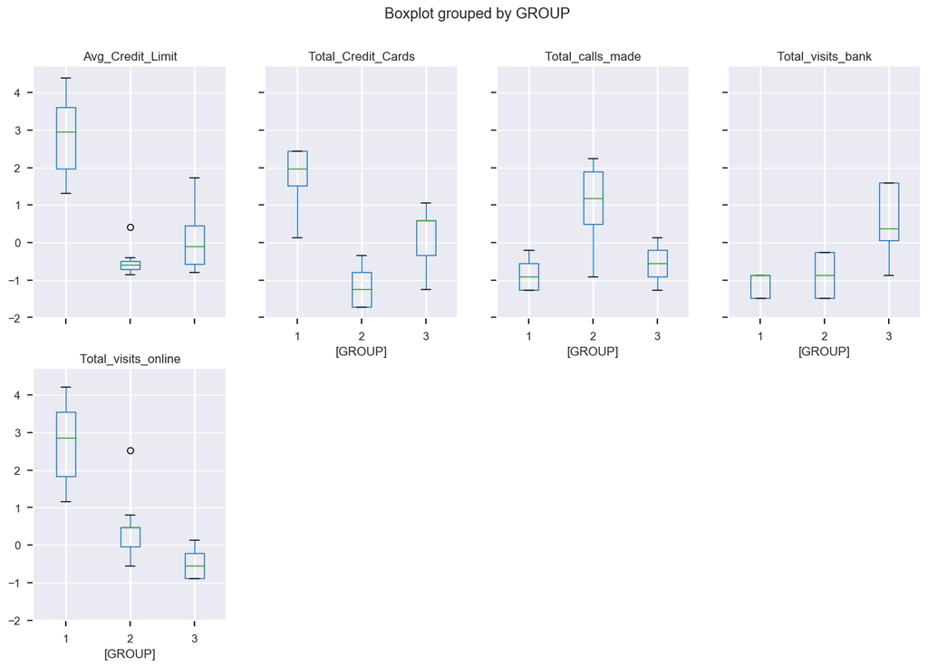

```python
df_z.boxplot(by='GROUP', layout = (2,4),figsize=(15,10))
```

# Complete linkage

```python
df_z.drop(columns = {'GROUP'}, inplace=True)
```

```python
df_z.shape
```

```
(660, 5)
```

```python
Z_Complete = linkage(df_z, metric='euclidean', method='complete')
c, coph_dists = cophenet(Z_Complete , pdist(df_z))

c
```

```
0.8599730607972423
```

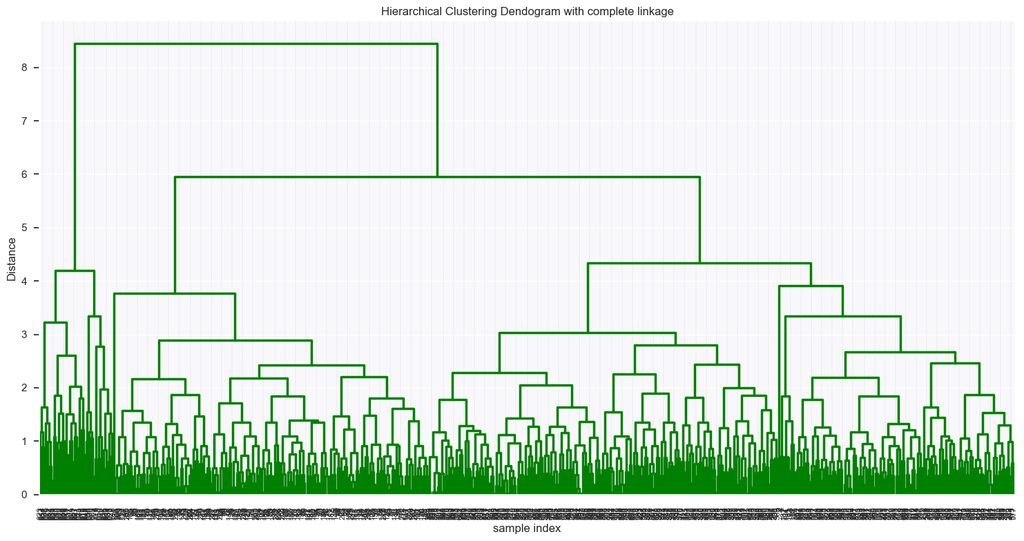

```python
plt.figure(figsize=(15, 8))
plt.title('Hierarchical Clustering Dendogram with complete linkage')
plt.xlabel('sample index')
plt.ylabel('Distance')
dendrogram(Z_Complete, leaf_rotation=90.,color_threshold = 40, leaf_font_size=8. )
plt.tight_layout()
```

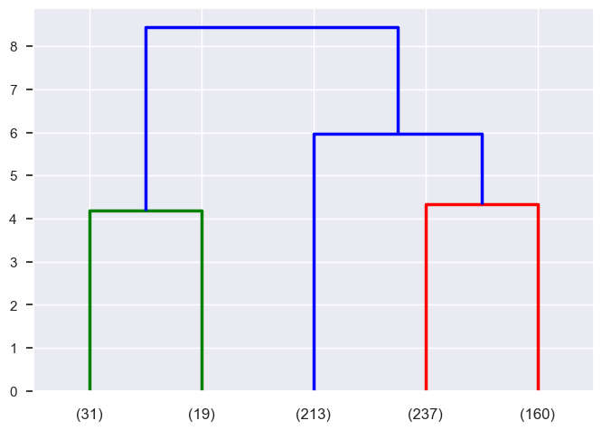

```python
# Hint: Use truncate_mode='lastp' attribute in dendrogram function to arrive at dendrogram
dendrogram(
    Z_Complete,
    truncate_mode='lastp',  # show only the last p merged clusters
    p=5,  # show only the last p merged clusters
)
plt.show()
```

```python
completeLinkageClusters = fcluster(Z_Complete,5, criterion='maxclust')
```

```python
df["GROUP"] = completeLinkageClusters
df_z["GROUP"] = completeLinkageClusters
print("Groups Assigned : \n")
df.head()
```

```
Groups Assigned :
```

| Sl_No | Avg_Credit_Limit | Total_Credit_Cards | Total_visits_bank | Total_visits_online | Total_calls_made | GROUP |
| --- | --- | --- | --- | --- | --- | --- |
| 1 | 100000 | 2 | 1 | 1 | 0 | 5 |
| 2 | 50000 | 3 | 0 | 10 | 9 | 3 |
| 3 | 50000 | 7 | 1 | 3 | 4 | 5 |
| 4 | 30000 | 5 | 1 | 1 | 4 | 5 |
| 5 | 100000 | 6 | 0 | 12 | 3 | 2 |

```
array([[<matplotlib.axes._subplots.AxesSubplot object at 0x000001C103136108>,
      dtype=object)
```

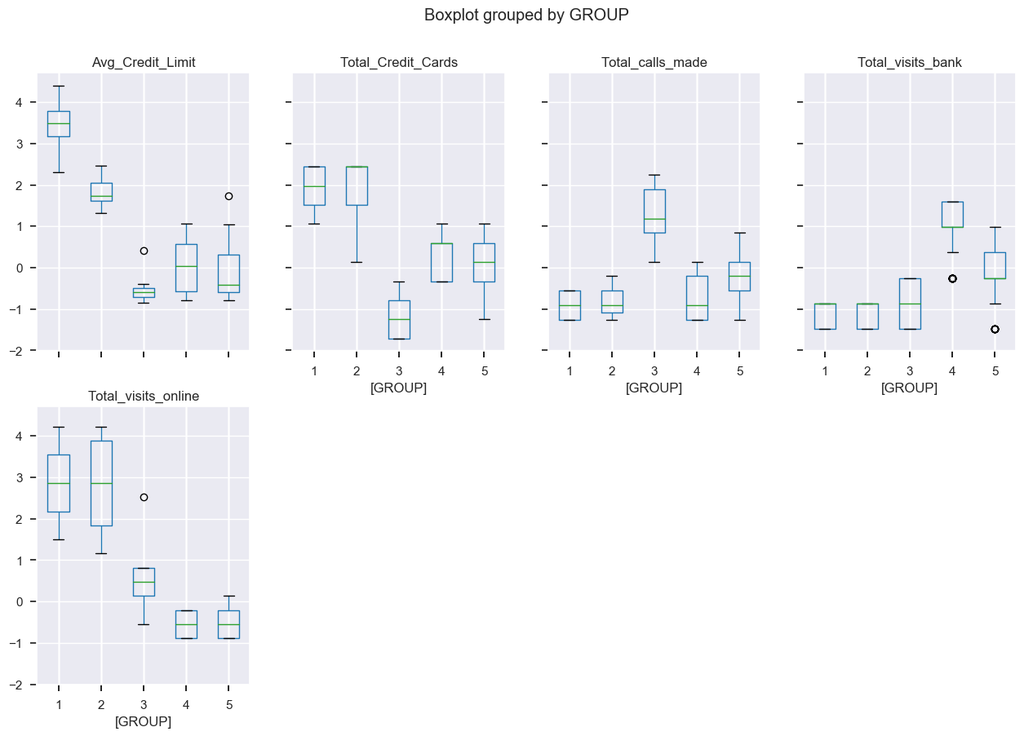

```python
df_z.boxplot(by='GROUP', layout = (2,4),figsize=(15,10))
```

# Ward linkage

```python
df_z.shape
```

```
(660, 6)
```

```python
df_z.drop(columns = {'GROUP'}, inplace=True)
```

```python
df_z.shape
```

```
(660, 5)
```

```python
Z_Ward = linkage(df_z, metric='euclidean', method='ward')
c, coph_dists = cophenet(Z_Ward , pdist(df_z))

c
```

```
0.7415156284827493
```

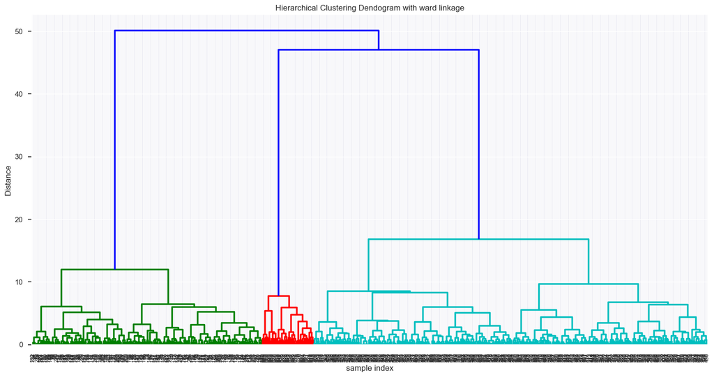

```python
plt.figure(figsize=(15, 8))
plt.title('Hierarchical Clustering Dendogram with ward linkage')
plt.xlabel('sample index')
plt.ylabel('Distance')
dendrogram(Z_Ward, leaf_rotation=90.,color_threshold = 40, leaf_font_size=8. )
plt.tight_layout()
```

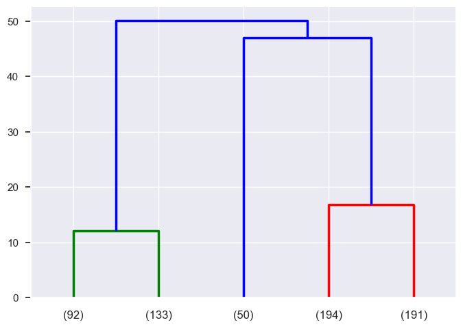

```python
# Hint: Use truncate_mode='lastp' attribute in dendrogram function to arrive at dendrogram
dendrogram(
    Z_Ward,
    truncate_mode='lastp',  # show only the last p merged clusters
    p=5,  # show only the last p merged clusters
)
plt.show()
```

```python
wardLinkageClusters = fcluster(Z_Ward,5, criterion='maxclust')
```

```python
df["GROUP"] = wardLinkageClusters
df_z["GROUP"] = wardLinkageClusters
print("Groups Assigned : \n")
df.head()
```

```
Groups Assigned :
```

| Sl_No | Avg_Credit_Limit | Total_Credit_Cards | Total_visits_bank | Total_visits_online | Total_calls_made | GROUP |
| --- | --- | --- | --- | --- | --- | --- |
| 1 | 100000 | 2 | 1 | 1 | 0 | 5 |
| 2 | 50000 | 3 | 0 | 10 | 9 | 1 |
| 3 | 50000 | 7 | 1 | 3 | 4 | 5 |
| 4 | 30000 | 5 | 1 | 1 | 4 | 5 |
| 5 | 100000 | 6 | 0 | 12 | 3 | 3 |

```
array([[<matplotlib.axes._subplots.AxesSubplot object at 0x000001C109987888>,
      dtype=object)
```

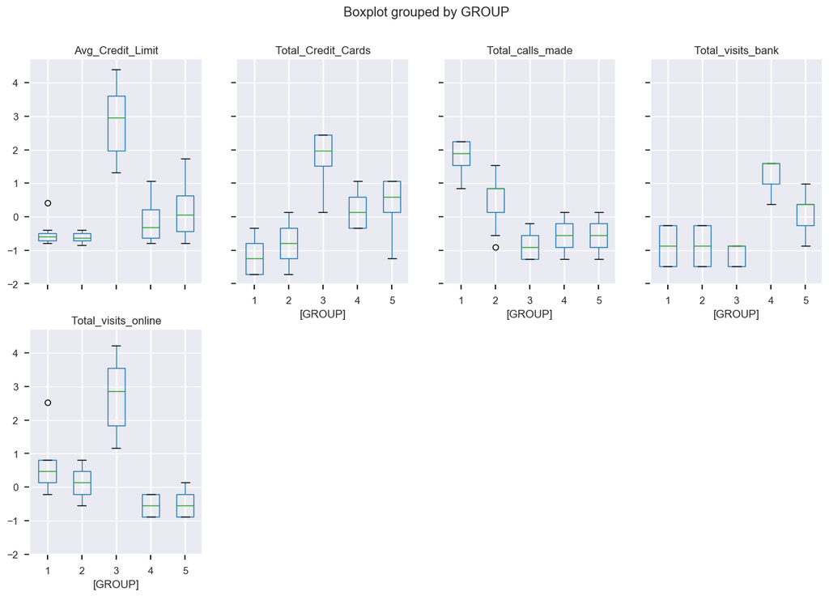

```python
df_z.boxplot(by='GROUP', layout = (2,4),figsize=(15,10))
```

# 5. Calculate average silhouette score for both methods. (5 marks)

```python
df_z.shape
```

```
(660, 6)
```

```python
df_z.drop(columns = {'GROUP'}, inplace=True)
```

```python
df_z.shape
```

```
(660, 5)
```

```python
from sklearn.metrics import silhouette_samples, silhouette_score
kMeans2Silhouette = silhouette_score(df_z,prediction2)
kMeans2Silhouette
```

```
0.41842496663215445
```

```python
kMeans3Silhouette = silhouette_score(df_z,prediction3)
kMeans3Silhouette
```

```
0.5157182558881063
```

```python
kMeans4Silhouette = silhouette_score(df_z,prediction4)
kMeans4Silhouette
```

```
0.3557860871310981
```

```python
avgLinkageSilhouette = silhouette_score(df_z,avgLinkageClusters)
avgLinkageSilhouette
```

```
0.515922432650965
```

```python
completeLinkageSilhouette = silhouette_score(df_z,completeLinkageClusters)
completeLinkageSilhouette
# Comment - if we reduce clusters to 3 then this score will increase
```

```
0.2795859403678087
```

```python
wardLinkageSilhouette = silhouette_score(df_z,wardLinkageClusters)
wardLinkageSilhouette
```

```
0.2569177732675831
```

# 6. Compare K-means clusters with Hierarchical clusters. (5 marks)

K-means clustering and Hierarchical clustering cannot be really compared directly.

If we look at Elbow method for K-means, we can optimized clustering using 2,3 and 4 clusters. Out of these 3 numbers, 3 cluster K-means give better silhouette score.

With hierarchical clustering, we are using 3 different methods (Average, Complete and Ward) for linkage clustering.

Cophenet index(closer to 1, better clustering)

1. Average Linkage : 0.8977080867389372
2. Complete Linkage : 0.8599730607972423
3. Ward Linkage : 0.7415156284827493

Out of which, average linkage has best cophenet index.

To attempt comparing K-means and Hierarchical clustering, I used boxplot using fcluster for Hierarchical clustering.

In this attempt, if we use distance as a measure then sometime, all rows are present in only one cluster. To make comparison better, I have used 'maxclust' as criteria for fcluster. In this case,3 value for 'maxclust' gives best silhouette score.

I am going to compare K-means 3 cluster and hierarchical clustering - Average Linkage with 3 clusters below.

```python
#K-means 3 cluster labels
prediction3
```

```
array([0, 1, 0, 0, 2, 1, 2, 1, 1, 1, 1, 1, 1, 1, 1, 1, 1, 1, 1, 1, 1, 1,
       1, 1, 1, 1, 1, 1, 1, 1, 1, 1, 1, 1, 1, 1, 1, 1, 1, 1, 1, 1, 1, 1,
       1, 1, 1, 1, 1, 1, 1, 1, 1, 1, 1, 1, 1, 1, 1, 1, 1, 1, 1, 1, 1, 1,
       1, 1, 1, 1, 1, 1, 1, 1, 1, 1, 1, 1, 1, 1, 1, 1, 1, 1, 1, 1, 1, 1,
       1, 1, 1, 1, 1, 1, 1, 1, 1, 1, 1, 1, 1, 1, 1, 1, 1, 1, 1, 1, 1, 1,
       1, 1, 1, 1, 1, 1, 1, 1, 1, 1, 1, 1, 1, 1, 1, 1, 1, 1, 1, 1, 1, 1,
       1, 1, 1, 1, 1, 1, 1, 1, 1, 1, 1, 1, 1, 1, 1, 1, 1, 1, 1, 1, 1, 1,
       1, 1, 1, 1, 1, 1, 1, 1, 1, 1, 1, 1, 1, 1, 1, 1, 1, 1, 1, 1, 1, 1,
       1, 1, 1, 1, 1, 1, 1, 1, 1, 1, 1, 1, 1, 1, 1, 1, 1, 1, 1, 1, 1, 1,
       1, 1, 1, 1, 1, 1, 1, 1, 1, 1, 1, 1, 1, 1, 1, 1, 1, 1, 1, 1, 1, 1,
       1, 1, 1, 1, 1, 1, 1, 1, 0, 0, 0, 0, 0, 0, 0, 0, 0, 0, 0, 0, 0, 0,
       0, 0, 0, 0, 0, 0, 0, 0, 0, 0, 0, 0, 0, 0, 0, 0, 0, 0, 0, 0, 0, 0,
       0, 0, 0, 0, 0, 0, 0, 0, 0, 0, 0, 0, 0, 0, 0, 0, 0, 0, 0, 0, 0, 0,
       0, 0, 0, 0, 0, 0, 0, 0, 0, 0, 0, 0, 0, 0, 0, 0, 0, 0, 0, 0, 0, 0,
       0, 0, 0, 0, 0, 1, 0, 0, 0, 0, 0, 0, 0, 0, 0, 0, 0, 0, 0, 0, 0, 0,
       0, 0, 0, 0, 0, 0, 0, 0, 0, 0, 0, 0, 0, 0, 0, 0, 0, 0, 0, 0, 0, 0,
       0, 0, 0, 0, 0, 0, 0, 0, 0, 0, 0, 0, 0, 0, 0, 0, 0, 0, 0, 0, 0, 0,
       0, 0, 0, 0, 0, 0, 0, 0, 0, 0, 0, 0, 0, 0, 0, 0, 0, 0, 0, 0, 0, 0,
       0, 0, 0, 0, 0, 0, 0, 0, 0, 0, 0, 0, 0, 0, 0, 0, 0, 0, 0, 0, 0, 0,
       0, 0, 0, 0, 0, 0, 0, 0, 0, 0, 0, 0, 0, 0, 0, 0, 0, 0, 0, 0, 0, 0,
       0, 0, 0, 0, 0, 0, 0, 0, 0, 0, 0, 0, 0, 0, 0, 0, 0, 0, 0, 0, 0, 0,
       0, 0, 0, 0, 0, 0, 0, 0, 0, 0, 0, 0, 0, 0, 0, 0, 0, 0, 0, 0, 0, 0,
       0, 0, 0, 0, 0, 0, 0, 0, 0, 0, 0, 0, 0, 0, 0, 0, 0, 0, 0, 0, 0, 0,
       0, 0, 0, 0, 0, 0, 0, 0, 0, 0, 0, 0, 0, 0, 0, 0, 0, 0, 0, 0, 0, 0,
       0, 0, 0, 0, 0, 0, 0, 0, 0, 0, 0, 0, 0, 0, 0, 0, 0, 0, 0, 0, 0, 0,
       0, 0, 0, 0, 0, 0, 0, 0, 0, 0, 0, 0, 0, 0, 0, 0, 0, 0, 0, 0, 0, 0,
       0, 0, 0, 0, 0, 0, 0, 0, 0, 0, 0, 0, 0, 0, 0, 0, 0, 0, 0, 0, 0, 0,
       0, 0, 0, 0, 0, 0, 0, 0, 0, 0, 0, 0, 0, 0, 0, 0, 0, 0, 2, 2, 2, 2,
       2, 2, 2, 2, 2, 2, 2, 2, 2, 2, 2, 2, 2, 2, 2, 2, 2, 2, 2, 2, 2, 2,
       2, 2, 2, 2, 2, 2, 2, 2, 2, 2, 2, 2, 2, 2, 2, 2, 2, 2, 2, 2, 2, 2])
```

```python
#hierarchical clustering - Average Linkage with 3 clusters labels
avgLinkageClusters
```

```
array([3, 2, 3, 3, 1, 2, 1, 2, 2, 2, 2, 2, 2, 2, 2, 2, 2, 2, 2, 2, 2, 2,
       2, 2, 2, 2, 2, 2, 2, 2, 2, 2, 2, 2, 2, 2, 2, 2, 2, 2, 2, 2, 2, 2,
       2, 2, 2, 2, 2, 2, 2, 2, 2, 2, 2, 2, 2, 2, 2, 2, 2, 2, 2, 2, 2, 2,
       2, 2, 2, 2, 2, 2, 2, 2, 2, 2, 2, 2, 2, 2, 2, 2, 2, 2, 2, 2, 2, 2,
       2, 2, 2, 2, 2, 2, 2, 2, 2, 2, 2, 2, 2, 2, 2, 2, 2, 2, 2, 2, 2, 2,
       2, 2, 2, 2, 2, 2, 2, 2, 2, 2, 2, 2, 2, 2, 2, 2, 2, 2, 2, 2, 2, 2,
       2, 2, 2, 2, 2, 2, 2, 2, 2, 2, 2, 2, 2, 2, 2, 2, 2, 2, 2, 2, 2, 2,
       2, 2, 2, 2, 2, 2, 2, 2, 2, 2, 2, 2, 2, 2, 2, 2, 2, 2, 2, 2, 2, 2,
       2, 2, 2, 2, 2, 2, 2, 2, 2, 2, 2, 2, 2, 2, 2, 2, 2, 2, 2, 2, 2, 2,
       2, 2, 2, 2, 2, 2, 2, 2, 2, 2, 2, 2, 2, 2, 2, 2, 2, 2, 2, 2, 2, 2,
       2, 2, 2, 2, 2, 2, 2, 2, 3, 3, 3, 3, 3, 3, 3, 3, 3, 3, 3, 3, 3, 3,
       3, 3, 3, 3, 3, 3, 3, 3, 3, 3, 3, 3, 3, 3, 3, 3, 3, 3, 3, 3, 3, 3,
       3, 3, 3, 3, 3, 3, 3, 3, 3, 3, 3, 3, 3, 3, 3, 3, 3, 3, 3, 3, 3, 3,
       3, 3, 3, 3, 3, 3, 3, 3, 3, 3, 3, 3, 3, 3, 3, 3, 3, 3, 3, 3, 3, 3,
       3, 3, 3, 3, 3, 3, 3, 3, 3, 3, 3, 3, 3, 3, 3, 3, 3, 3, 3, 3, 3, 3,
```

[output cut: 16 more lines]

```python
df["KMeans3GROUP"] = prediction3
df_z["KMeans3GROUP"] = prediction3
df["AvgLink3GROUP"] = avgLinkageClusters
df_z["AvgLink3GROUP"] = avgLinkageClusters

df
```

| Sl_No | Avg_Credit_Limit | Total_Credit_Cards | Total_visits_bank | Total_visits_online | Total_calls_made | GROUP | KMeans3GROUP | AvgLink3GROUP |
| --- | --- | --- | --- | --- | --- | --- | --- | --- |
| 1 | 100000 | 2 | 1 | 1 | 0 | 5 | 0 | 3 |
| 2 | 50000 | 3 | 0 | 10 | 9 | 1 | 1 | 2 |
| 3 | 50000 | 7 | 1 | 3 | 4 | 5 | 0 | 3 |
| 4 | 30000 | 5 | 1 | 1 | 4 | 5 | 0 | 3 |
| 5 | 100000 | 6 | 0 | 12 | 3 | 3 | 2 | 1 |
| 6 | 20000 | 3 | 0 | 1 | 8 | 2 | 1 | 2 |
| 7 | 100000 | 5 | 0 | 11 | 2 | 3 | 2 | 1 |
| 8 | 15000 | 3 | 0 | 1 | 1 | 2 | 1 | 2 |
| 9 | 5000 | 2 | 0 | 2 | 2 | 2 | 1 | 2 |
| 10 | 3000 | 4 | 0 | 1 | 7 | 2 | 1 | 2 |
| 11 | 10000 | 4 | 0 | 5 | 5 | 2 | 1 | 2 |
| 12 | 13000 | 3 | 0 | 2 | 7 | 2 | 1 | 2 |
| 13 | 11000 | 1 | 2 | 5 | 9 | 1 | 1 | 2 |
| 14 | 9000 | 1 | 1 | 5 | 6 | 2 | 1 | 2 |
| 15 | 6000 | 2 | 2 | 4 | 6 | 2 | 1 | 2 |
| 16 | 8000 | 2 | 0 | 5 | 7 | 1 | 1 | 2 |
| 17 | 15000 | 2 | 1 | 2 | 4 | 2 | 1 | 2 |
| 18 | 8000 | 2 | 0 | 3 | 4 | 2 | 1 | 2 |
| 19 | 11000 | 2 | 2 | 2 | 7 | 2 | 1 | 2 |
| 20 | 19000 | 4 | 1 | 5 | 8 | 2 | 1 | 2 |
| 21 | 5000 | 3 | 2 | 5 | 5 | 2 | 1 | 2 |
| 22 | 16000 | 2 | 0 | 3 | 7 | 1 | 1 | 2 |
| 23 | 6000 | 4 | 1 | 4 | 6 | 2 | 1 | 2 |
| 24 | 9000 | 1 | 1 | 3 | 4 | 2 | 1 | 2 |
| 25 | 8000 | 2 | 0 | 2 | 10 | 1 | 1 | 2 |
| 26 | 18000 | 1 | 1 | 5 | 10 | 1 | 1 | 2 |
| 27 | 16000 | 3 | 0 | 5 | 9 | 1 | 1 | 2 |
| 28 | 9000 | 2 | 2 | 2 | 10 | 1 | 1 | 2 |
| 29 | 5000 | 2 | 0 | 4 | 6 | 2 | 1 | 2 |
| 30 | 8000 | 4 | 0 | 4 | 7 | 2 | 1 | 2 |
| ... | ... | ... | ... | ... | ... | ... | ... | ... |
| 631 | 200000 | 10 | 0 | 13 | 0 | 3 | 2 | 1 |
| 632 | 195000 | 8 | 0 | 15 | 0 | 3 | 2 | 1 |
| 633 | 187000 | 7 | 1 | 7 | 0 | 3 | 2 | 1 |
| 634 | 163000 | 7 | 1 | 10 | 1 | 3 | 2 | 1 |
| 635 | 106000 | 8 | 0 | 8 | 1 | 3 | 2 | 1 |
| 636 | 114000 | 10 | 1 | 7 | 2 | 3 | 2 | 1 |
| 637 | 126000 | 10 | 1 | 8 | 0 | 3 | 2 | 1 |
| 638 | 173000 | 9 | 1 | 11 | 0 | 3 | 2 | 1 |
| 639 | 153000 | 8 | 1 | 7 | 1 | 3 | 2 | 1 |
| 640 | 184000 | 7 | 1 | 15 | 2 | 3 | 2 | 1 |
| 641 | 123000 | 8 | 1 | 15 | 2 | 3 | 2 | 1 |
| 642 | 144000 | 10 | 0 | 10 | 2 | 3 | 2 | 1 |
| 643 | 97000 | 10 | 1 | 9 | 2 | 3 | 2 | 1 |
| 644 | 98000 | 9 | 0 | 8 | 2 | 3 | 2 | 1 |
| 645 | 127000 | 10 | 1 | 15 | 1 | 3 | 2 | 1 |
| 646 | 171000 | 10 | 0 | 15 | 0 | 3 | 2 | 1 |
| 647 | 186000 | 7 | 0 | 8 | 1 | 3 | 2 | 1 |
| 648 | 183000 | 9 | 0 | 9 | 2 | 3 | 2 | 1 |
| 649 | 111000 | 8 | 1 | 7 | 0 | 3 | 2 | 1 |
| 650 | 112000 | 10 | 1 | 8 | 1 | 3 | 2 | 1 |
| 651 | 195000 | 10 | 1 | 12 | 2 | 3 | 2 | 1 |
| 652 | 132000 | 9 | 1 | 12 | 2 | 3 | 2 | 1 |
| 653 | 156000 | 8 | 1 | 8 | 0 | 3 | 2 | 1 |
| 654 | 95000 | 10 | 0 | 15 | 1 | 3 | 2 | 1 |
| 655 | 172000 | 10 | 1 | 9 | 1 | 3 | 2 | 1 |
| 656 | 99000 | 10 | 1 | 10 | 0 | 3 | 2 | 1 |
| 657 | 84000 | 10 | 1 | 13 | 2 | 3 | 2 | 1 |
| 658 | 145000 | 8 | 1 | 9 | 1 | 3 | 2 | 1 |
| 659 | 172000 | 10 | 1 | 15 | 0 | 3 | 2 | 1 |
| 660 | 167000 | 9 | 0 | 12 | 2 | 3 | 2 | 1 |

660 rows × 8 columns

```python
df_z.columns
```

```
Index(['Avg_Credit_Limit', 'Total_Credit_Cards', 'Total_visits_bank',
       'Total_visits_online', 'Total_calls_made', 'KMeans3GROUP',
       'AvgLink3GROUP'],
      dtype='object')
```

```
array([[<matplotlib.axes._subplots.AxesSubplot object at 0x000001C109381488>,
      dtype=object)
```

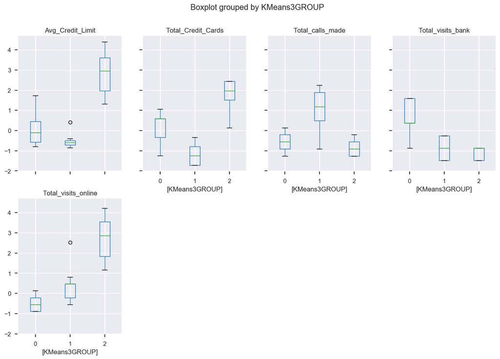

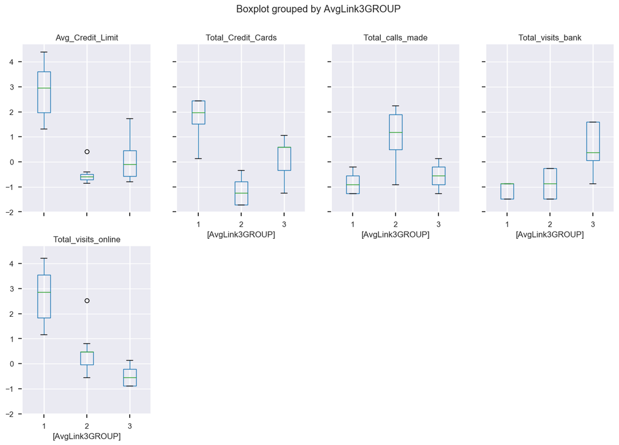

```python
df_z.drop(columns = {'AvgLink3GROUP'}, inplace=True)
df_z.boxplot(by='KMeans3GROUP', layout = (2,4),figsize=(15,10))
df_z.drop(columns = {'KMeans3GROUP'}, inplace=True)
df["AvgLink3GROUP"] = avgLinkageClusters
df_z["AvgLink3GROUP"] = avgLinkageClusters
df_z.boxplot(by='AvgLink3GROUP', layout = (2,4),figsize=(15,10))
```

From above comparison, the cluster group to which each row of data belong may be different using Kmeans and Hierarchical clustering. but from boxplot, for each variable, three different groups for each variable are identical using both methods.

Clustering is very subjective. If we have an idea of segments or groups within data using EDA (data analysis), then it is optimal to use K-means. It may be computationally faster than hierarchical clustering.

Hierarchical clustering is a structure that is more informative and interpretable than clusters by k-means.Therefore, it is easier to determine the optimal number of clusters by looking at the dendrogram of a hierarchical clustering than trying to predict this optimal number in advance in case of k-means.

# 7. Analysis the clusters formed, tell us how is one cluster different from another and answer all the key questions. (10 marks)

# Problem Statement

Project description provides following problem statement.

Objective: To identify different segments in the existing customer based on their spending patterns as well as past interaction with the bank. Key Questions:

1. How many different segments of customers are there?
2. How are these segments different from each other?
3. What are your recommendations to the bank on how to better market to and service these customers?

The 'Avg_Credit_Limit' information is used for determining spending ability.

I am going to use K-means 3 clustering as Hierarchical Average Linkage provides similar clustering.

# K-Means Clustering with 3 Cluster Ids

```python
df.drop(columns = {'GROUP','KMeans3GROUP','AvgLink3GROUP'}, inplace=True)
df.describe().transpose()
```

|  | count | mean | std | min | 25% | 50% | 75% | max |
| --- | --- | --- | --- | --- | --- | --- | --- | --- |
| Avg_Credit_Limit | 660.0 | 34574.242424 | 37625.487804 | 3000.0 | 10000.0 | 18000.0 | 48000.0 | 200000.0 |
| Total_Credit_Cards | 660.0 | 4.706061 | 2.167835 | 1.0 | 3.0 | 5.0 | 6.0 | 10.0 |
| Total_visits_bank | 660.0 | 2.403030 | 1.631813 | 0.0 | 1.0 | 2.0 | 4.0 | 5.0 |
| Total_visits_online | 660.0 | 2.606061 | 2.935724 | 0.0 | 1.0 | 2.0 | 4.0 | 15.0 |
| Total_calls_made | 660.0 | 3.583333 | 2.865317 | 0.0 | 1.0 | 3.0 | 5.0 | 10.0 |

```python
df3Clust.count()
```

| GROUP | Avg_Credit_Limit | Total_Credit_Cards | Total_visits_bank | Total_visits_online | Total_calls_made |
| --- | --- | --- | --- | --- | --- |
| 0 | 386 | 386 | 386 | 386 | 386 |
| 1 | 224 | 224 | 224 | 224 | 224 |
| 2 | 50 | 50 | 50 | 50 | 50 |

```python
# K-means 3 cluster distribution - df3Clust calcuted above
df3Clust.median()
```

| GROUP | Avg_Credit_Limit | Total_Credit_Cards | Total_visits_bank | Total_visits_online | Total_calls_made |
| --- | --- | --- | --- | --- | --- |
| 0 | 31000 | 6 | 3 | 1 | 2 |
| 1 | 12000 | 2 | 1 | 4 | 7 |
| 2 | 145500 | 9 | 1 | 11 | 1 |

```python
df3Clust.mean()
```

| GROUP | Avg_Credit_Limit | Total_Credit_Cards | Total_visits_bank | Total_visits_online | Total_calls_made |
| --- | --- | --- | --- | --- | --- |
| 0 | 33782.383420 | 5.515544 | 3.489637 | 0.981865 | 2.000000 |
| 1 | 12174.107143 | 2.410714 | 0.933036 | 3.553571 | 6.870536 |
| 2 | 141040.000000 | 8.740000 | 0.600000 | 10.900000 | 1.080000 |

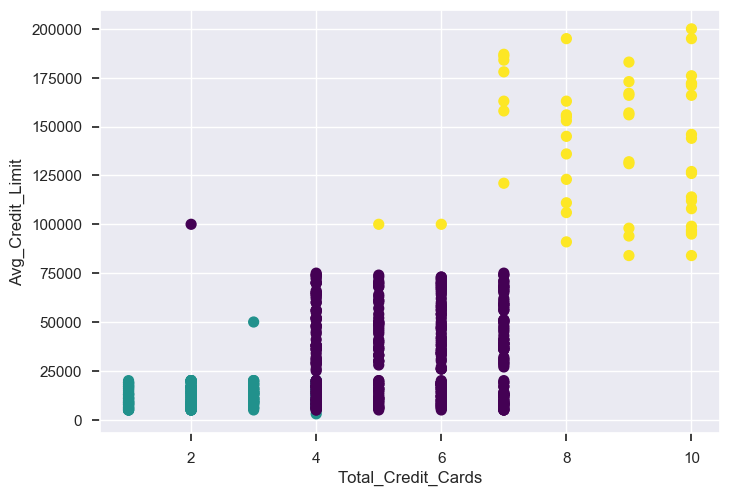

```python
centers = kmeans3model.cluster_centers_

plt.scatter(df['Total_Credit_Cards'], df['Avg_Credit_Limit'], c=prediction3, s=50, cmap='viridis')
plt.xlabel('Total_Credit_Cards')
plt.ylabel('Avg_Credit_Limit')
plt.show()
```

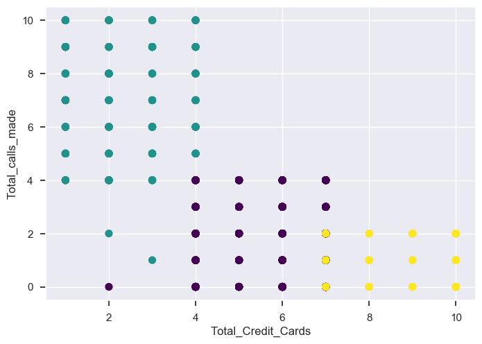

```python
plt.scatter(df['Total_Credit_Cards'], df['Total_calls_made'], c=prediction3, s=50, cmap='viridis')
plt.xlabel('Total_Credit_Cards')
plt.ylabel('Total_calls_made')
plt.show()
```

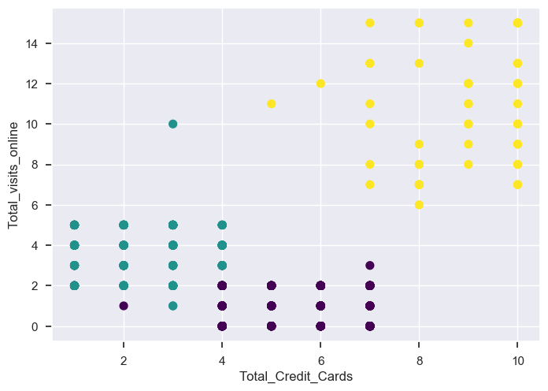

```python
plt.scatter(df['Total_Credit_Cards'], df['Total_visits_online'], c=prediction3, s=50, cmap='viridis')
plt.xlabel('Total_Credit_Cards')
plt.ylabel('Total_visits_online')
plt.show()
```

# Different Segments

3 Segments

Description of segments:

Those have average spending ability or in middle of range of spending ability - they like to visit bank. The customers with high spending ability always prefer online interaction. They are not interested in any other form of interaction. Where as customers with low spending ability prefer phone interaction but also use online communication/transaction.

# Suggestions

To increase penetration of customers,

Maximum customers(Group 0 - 386) perfer visiting bank. so bank should have dedicated service department or improve their existing customer service. Bank can also call these customers periodically. It would be worth looking at training this segement for online interaction. Bank can further classify different customer queries.

For recommendation, this data is not enough. It would be helpful if we have some more information like salary/bank balance, amount of money spent and categories on which customers are spending money, queries that are taking more time.